# Non-stationary conditional extremes for BC streamflow: the code report (v4, meeting-62 rebuild)

Alex Lin (supervisor: Natalia Nolde)

August 18, 2026

This report is the working pipeline for the paper *Non-stationary modelling of stream flow extremes under climate change scenarios*: one pair first — Case 4, BRIDG given NTHMB, with Case 1 (BARRM given BARRS) as the asymptotic-dependence anchor (v8 1, p. 2; 5, p. 12). Every reference of the form “v8 $x$, eq. ($n$), p. $y$” points into *my current understanding of the model*, version 8. Four design facts orient everything below.

**The working scale is Laplace** (v8 3, eq. 6, p. 4; Keef et al. 2013, eq. 2.1): both tails exactly exponential, so one parametric form covers positive and negative association with $a \in [-1,1]$ (v8 5, eq. 8, p. 11), and the Keef parameter constraints police extrapolation (v8 5, eq. 9, p. 13).

**The margins carry the seasonal cycle alongside the trend.** The marginal diagnostic of v8 3 (p. 4) failed in review — the PIT showed a clear seasonal shape — so the repair v8 4.2 (p. 7) names is adopted: the single-$t$ basis is swapped for one that contains a shared periodic day-of-year cycle next to the trend spline, coefficients, penalty and fitting unchanged. The threshold now moves with the seasons within each year, and “roughly 5% above the threshold” becomes checkable *locally* — per season and per decade — not just pooled. One consequence is flagged for discussion: with a seasonal threshold, “extreme” means extreme relative to the season, so a winter exceedance is a modest absolute flow; the annual return level (v8 6, eq. 12, p. 14) is unaffected, but the reading of the dependence-stage conditioning event changes and should be agreed explicitly.

**Data are cleaned before anything is fitted.** All of 1968 is discarded; the forensics section hunts the repeated values, the low-flow floor and the winter quality problems, and reports evidence — which days, which values, which months — so the exclusion decisions can be made deliberately and documented in the paper. No exclusion beyond 1968 is applied silently.

**Packages are production where they exist** (v8 4.5, p. 9): qgam for the threshold ladder (automatic smoothing; its three recorded costs — no non-crossing constraint, iid calibration theory, care at extreme rungs — are v8 4.4, p. 9, and each is handled below), evgam for the GP tail, extRemes for the extremal index, texmex and mgcv as the dependence checks. The dependence fitter itself is project code: no package fits the non-stationary Heffernan–Tawn model. The routes table states the intent; each stage table below reports the route actually used after any fallback.

```r
route <- data.frame(
  stage = c("threshold ladder", "GP tail", "extremal index",
            "dependence fitter", "dependence checks"),
  production = c(
    ifelse(has["qgam"], "qgam/mqgam (seasonal + trend)", "project pen_rq (fallback)"),
    ifelse(has["evgam"], "evgam (gpd, seasonal + trend)", "project fit_gp (fallback)"),
    ifelse(has["extRemes"], "extRemes::extremalindex", "project ferro_segers (fallback)"),
    "project ht fitter with Keef constraints (no package exists)",
    paste0("tier 1 texmex: ", ifelse(has["texmex"], "on", "off"),
           " | tier 2 mgcv: ", ifelse(has["mgcv"], "on", "off"))))
knitr::kable(route, caption = "Software routes this knit -- the INTENT. The
stage tables below each report the route actually used after any tryCatch
fallback; trust those, not this one.")
```

Software routes this knit – the INTENT. The stage tables below each report the route actually used after any tryCatch fallback; trust those, not this one.

| stage | production |
| --- | --- |
| threshold ladder | qgam/mqgam (seasonal + trend) |
| GP tail | evgam (gpd, seasonal + trend) |
| extremal index | extRemes::extremalindex |
| dependence fitter | project ht fitter with Keef constraints (no package exists) |
| dependence checks | tier 1 texmex: on \| tier 2 mgcv: on |

# 1 Data, axis, integrity gates

The file is the definitive RCP 4.5 export; the axis is its extent *after* the 1968 drop (v8 1, p. 1: RCP 4.5 alone; meeting 62: discard 1968).

```r
raw <- read.csv("/Users/alexlin/Downloads/EDA/daily_sf_bf_rcp45_only_1945_2099_9avg.csv",
                colClasses = c("character", "character", "numeric", "numeric"))
names(raw) <- c("station", "date", "sf", "bf")
raw$date <- as.Date(raw$date)
raw$year <- as.integer(format(raw$date, "%Y"))

## integrity gates on the RAW file, before the 1968 drop
dup_rows <- sum(duplicated(raw[, c("station", "date")]))
cat("duplicated (station, date) rows in the file:", dup_rows, "\n")
```

```
## duplicated (station, date) rows in the file: 0
```

```r
full_seq <- seq(min(raw$date), max(raw$date), by = "day")
miss <- sapply(split(raw$date, raw$station),
               function(d) length(setdiff(full_seq, d)))
cat("missing dates per station (0 everywhere = continuous):",
    paste(range(miss), collapse = "-"), "\n")
```

```
## missing dates per station (0 everywhere = continuous): 0-0
```

```r
cat("NA counts: sf", sum(is.na(raw$sf)), "| bf", sum(is.na(raw$bf)), "\n")
```

```
## NA counts: sf 0 | bf 0
```

```r
cat("bf <= 0 days, worst stations:\n")
```

```
## bf <= 0 days, worst stations:
```

```r
bfneg <- sort(tapply(raw$bf <= 0, raw$station, sum), decreasing = TRUE)
print(head(bfneg[bfneg > 0], 5))
```

```
## named integer(0)
```

```r
keep1968 <- raw[raw$year < params$start_year, ]   # kept aside for forensics
d68 <- keep1968
raw <- raw[raw$year >= params$start_year, ]

a0 <- min(raw$date); a1 <- max(raw$date)
dates <- sort(unique(raw$date)); N <- length(dates)
years <- as.integer(format(dates, "%Y"))
months <- as.integer(format(dates, "%m"))
doy <- as.integer(format(dates, "%j"))
tt <- as.numeric(dates - a0) / as.numeric(a1 - a0)
span_yr <- as.numeric(a1 - a0) / 365.25

get_series <- function(st, var, df = raw) {
  d <- df[df$station == st, ]; d[[var]][order(d$date)]
}
C_st <- "NTHMB"; X_st <- "BRIDG"          # Case 4: X | C (v8 Sec 1, p. 2)
A_C <- "BARRS"; A_X <- "BARRM"            # Case 1 anchor (v8 Sec 5, p. 12)
xC <- get_series(C_st, "sf"); xX <- get_series(X_st, "sf")
xB <- get_series(X_st, "bf")              # Structure-B conditioning variable

stopifnot(length(xC) == N, length(xX) == N, !anyNA(c(xC, xX, xB)),
          all(xC > 0), all(xX > 0))
cat("Axis after cleaning gate:", format(a0), "to", format(a1), "-", N,
    "days,", round(span_yr, 1), "years\n")
```

```
## Axis after cleaning gate: 1969-01-01 to 2099-12-31 - 47847 days, 131 years
```

# 2 Data forensics (meeting 62, the first problem)

Three artifacts motivated this section, seen on the previous knit’s figures: a flat run in the pooled QQ plots ending in a jump near sample value $-2.4$, and two straight line segments hugging the axes of the joint pseudosample panel. Three candidate causes, in decreasing order of code-vs-data:

1. *a transform artifact*: the old transform clamped every day whose fitted probability fell below $10^{-5}$ to that single number, and $-\log(-\log 10^{-5}) = -2.44$ on the Gumbel scale — exactly the observed floor. All days far enough below the bottom ladder rung collapsed onto one point, which draws a flat QQ run ending in a jump, and straight lines in any joint scatter. Section 5’s rebuilt transform removes the clamp; its instrumentation counts the affected days so the artifact is quantified, not just repaired.
2. *repeated identical values in the data*: ties — from winter freezing floors, detection limits, or values entered more than once — put genuine point masses in the sample. Ties survive any honest transform (they are data, not code), and this section finds them: which values, which months, which years.
3. *the trend-only margins*: a threshold that cannot bend within a year maps winter days systematically low, so the bottom of the pooled sample is mostly December–February and any low-flow pathology concentrates there. Section 3’s seasonal threshold removes this confound; whatever remains after it is data, not design.

## 2.1 Repeated exact values: which, how often, when

```r
series_list <- list(`NTHMB sf` = xC, `BRIDG sf` = xX, `BRIDG bf` = xB)
month_lab <- function(m) paste(sort(unique(month.abb[m])), collapse = " ")
top_ties <- function(x, k = 10) {
  tb <- head(sort(table(x), decreasing = TRUE), k)
  do.call(rbind, lapply(names(tb), function(v) {
    i <- which(x == as.numeric(v))
    data.frame(value = as.numeric(v), n_days = length(i),
               years = paste(range(years[i]), collapse = "-"),
               n_years = length(unique(years[i])),
               months = month_lab(months[i]))
  }))
}
for (nm in names(series_list)) {
  cat("\n----", nm, ": the ten most repeated exact values ----\n")
  print(top_ties(series_list[[nm]]), row.names = FALSE)
  x <- series_list[[nm]]
  cat(sprintf("days whose value occurs >= 10 times: %d of %d (%.1f%%)\n",
      sum(x %in% as.numeric(names(which(table(x) >= 10)))), N,
      100 * mean(x %in% as.numeric(names(which(table(x) >= 10))))))
}
```

```
##
## ---- NTHMB sf : the ten most repeated exact values ----
##     value n_days     years n_years  months
##  25.24865      2 1985-2017       2 Dec Feb
##  26.12312      2 2013-2025       2 Feb Mar
##  29.40857      2 2033-2033       1     Mar
##  50.02669      2 1990-2048       2     Mar
##  51.69152      2 2078-2086       2 Feb Oct
##  57.65764      2 2029-2086       2 Apr Jan
##  59.69621      2 2056-2068       2 Oct Sep
##  63.49849      2 2056-2061       2 Apr Nov
##  64.96873      2 2001-2008       2     Nov
##  65.29144      2 1991-2062       2 Oct Sep
## days whose value occurs >= 10 times: 0 of 47847 (0.0%)
##
## ---- BRIDG sf : the ten most repeated exact values ----
##     value n_days     years n_years  months
##  1.473839      2 1973-2005       2 Feb Mar
##  5.170444      2 2007-2041       2     Jan
##  6.626955      2 2068-2084       2 Feb Jan
##  6.674022      2 2023-2038       2 Feb Jan
##  7.480022      2 2047-2061       2 Jan May
##  8.305540      2 2003-2056       2 Feb Jan
##  8.655244      2 2020-2086       2 Dec Feb
##  8.882268      2 2010-2049       2 Apr Jan
##  9.148898      2 2039-2084       2 Dec May
##  9.836550      2 1987-2090       2 Jan May
## days whose value occurs >= 10 times: 0 of 47847 (0.0%)
##
## ---- BRIDG bf : the ten most repeated exact values ----
##      value n_days     years n_years                          months
##  0.8096596     14 1972-2094      14 Apr Dec Feb Jan Mar May Nov Oct
##  0.8802753     14 1985-2093      13         Apr Dec Feb Jan Mar Oct
##  1.2926835     14 1995-2084      14     Apr Dec Feb Jan Nov Oct Sep
##  0.4269164     13 1972-2041      10                 Apr Feb Jan Mar
##  0.5126870     13 1975-2092      12                 Apr Feb Jan Mar
##  0.8341655     13 1980-2094      12             Apr Dec Feb Jan Mar
##  1.3636216     13 1994-2099      12     Apr Jan Mar May Nov Oct Sep
##  0.4101492     12 1976-2041      11                 Apr Feb Jan Mar
##  0.4178879     12 1977-2044      11             Apr Dec Feb Jan Mar
##  0.6049065     12 1970-2084      11                 Apr Feb Jan Mar
## days whose value occurs >= 10 times: 1447 of 47847 (3.0%)
```

**Reading the table.** One block per series. `value` is an exact repeated number; `n_days` how many days carry it; `years`/`n_years` when; `months` where in the year. What to look for: a value repeated hundreds of times in DJF across many years is a winter measurement floor (freezing); a value repeated only within one or two years is closer to a data-entry duplicate — the professor’s question “which values are these, and is it only that year” is answered by these columns. Large `n_days` at the series minimum is the floor that drew the QQ jump.

## 2.2 Distinct values per year, and runs of identical days

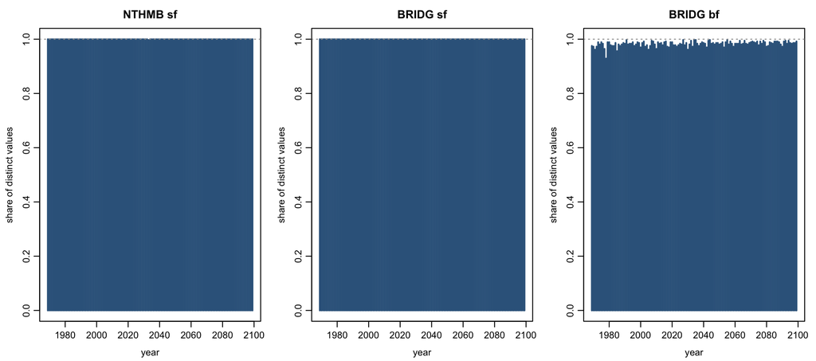

```r
op <- par(mfrow = c(1, 3), mar = c(3.5, 3.5, 2.5, 1), mgp = c(2.2, 0.7, 0))
yrs_u <- sort(unique(years))
for (nm in names(series_list)) {
  x <- series_list[[nm]]
  nd <- sapply(yrs_u, function(y) length(unique(x[years == y])) /
                                   sum(years == y))
  plot(yrs_u, nd, type = "h", lwd = 2, col = "steelblue4", ylim = c(0, 1),
       xlab = "year", ylab = "share of distinct values", main = nm)
  abline(h = 1, lty = 3, col = "grey60")
}
```

```r
par(op)

run_table <- function(x, minlen = 3) {
  r <- rle(x)
  i_end <- cumsum(r$lengths); i_start <- i_end - r$lengths + 1
  keep <- r$lengths >= minlen
  data.frame(start = dates[i_start[keep]], length = r$lengths[keep],
             value = r$values[keep], month = months[i_start[keep]])
}
for (nm in names(series_list)) {
  rt <- run_table(series_list[[nm]])
  cat("\n----", nm, sprintf(": %d runs of >= 3 identical consecutive days ----\n",
      nrow(rt)))
  if (nrow(rt) > 0) {
    print(head(rt[order(-rt$length), c("start", "length", "value")], 8),
          row.names = FALSE)
    print(table(month = rt$month))
  }
}
```

```
##
## ---- NTHMB sf : 0 runs of >= 3 identical consecutive days ----
##
## ---- BRIDG sf : 0 runs of >= 3 identical consecutive days ----
##
## ---- BRIDG bf : 4 runs of >= 3 identical consecutive days ----
##       start length     value
##  1971-03-20      4 0.1489680
##  1974-02-26      3 0.4462631
##  1985-03-06      3 0.3076114
##  2058-03-17      3 0.6142574
## month
## 2 3
## 1 3
```

**Reading the figure and tables.** Each panel: x-axis the year, bar height the share of that year’s 365 days carrying distinct values — 1.0 means no two days of the year had exactly equal flow; visibly short bars mean the year is full of repeats. The runs table shows consecutive identical days — a plateau: rivers vary daily, so a value frozen for a week is an instrument or post-processing signature, not hydrology. The month row of the table says where plateaus live; a DJF concentration is the freezing hypothesis confirmed in this series.

## 2.3 The floor: days at or near the minimum

```r
for (nm in names(series_list)) {
  x <- series_list[[nm]]
  at_min <- sum(x == min(x)); near <- sum(x <= min(x) * 1.01)
  cat(sprintf("\n%s: min = %.4f | days exactly at min: %d | within 1%%: %d\n",
      nm, min(x), at_min, near))
  if (at_min > 1) {
    i <- which(x == min(x))
    cat("  at-min days by month:\n"); print(table(month = months[i]))
    tab <- sort(table(years[i]), decreasing = TRUE)
    cat("  worst years:", paste(names(tab)[1:min(5, length(tab))],
        "(", tab[1:min(5, length(tab))], ")"), "\n")
  }
}
```

```
##
## NTHMB sf: min = 9.3511 | days exactly at min: 1 | within 1%: 4
##
## BRIDG sf: min = 0.6149 | days exactly at min: 1 | within 1%: 1
##
## BRIDG bf: min = 0.1480 | days exactly at min: 1 | within 1%: 6
```

**Reading the output.** A minimum carried by one day is ordinary; a minimum carried by dozens of days is a hard floor — a detection limit or a frozen gauge — and those are exactly the days the old clamp mapped to $-2.44$. Their month distribution says whether the floor is a winter phenomenon; their year distribution says whether it is confined to particular years (then a targeted exclusion is defensible) or endemic (then the handling is a modelling decision to discuss).

## 2.4 Winter windows, by eye

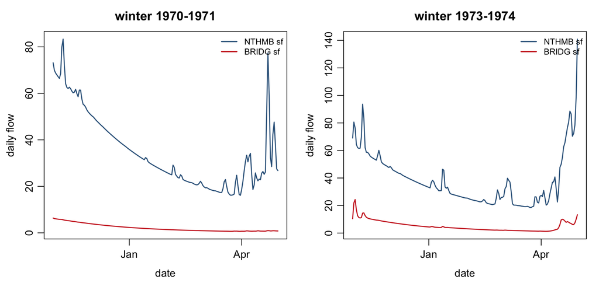

```r
rtX <- run_table(xX); rtC <- run_table(xC)
worst <- unique(c(format(rtX$start[order(-rtX$length)], "%Y"),
                  format(rtC$start[order(-rtC$length)], "%Y")))
worst <- as.integer(worst)
worst <- worst[!is.na(worst) & worst < max(years)]
worst <- unique(c(worst, yrs_u[2], yrs_u[5]))[1:2]
op <- par(mfrow = c(1, 2), mar = c(3.5, 3.5, 2.5, 1), mgp = c(2.2, 0.7, 0))
for (w in worst) {
  k <- dates >= as.Date(sprintf("%d-11-01", w)) &
       dates <= as.Date(sprintf("%d-04-30", w + 1))
  matplot(dates[k], cbind(xC[k], xX[k]), type = "l", lty = 1, lwd = 1.6,
          col = c("steelblue4", "firebrick3"), xlab = "date",
          ylab = "daily flow", main = sprintf("winter %d-%d", w, w + 1))
  legend("topright", c("NTHMB sf", "BRIDG sf"), lwd = 2, bty = "n",
         col = c("steelblue4", "firebrick3"), cex = 0.8)
}
```

```r
par(op)
```

## 2.5 1968 against its neighbours

```r
aud <- function(df, st, var) {
  x <- df[[var]][df$station == st]
  c(n = length(x), distinct = length(unique(x)),
    share_repeated = round(mean(x %in% as.numeric(names(which(table(x) >= 2)))), 3))
}
cmp <- rbind(`1968` = aud(d68, X_st, "sf"),
             do.call(rbind, lapply(params$start_year:(params$start_year + 4),
               function(y) aud(raw[raw$year == y, ], X_st, "sf"))))
rownames(cmp)[-1] <- params$start_year:(params$start_year + 4)
knitr::kable(cmp, caption = sprintf("BRIDG sf: 1968 (dropped) against the
first kept years -- sample size, distinct values, share of days whose value
repeats within the year. 1968 is excluded from the axis by decision
(meeting 62); this table records the evidence beside the decision."))
```

|  | n | distinct | share_repeated |
| --- | --- | --- | --- |
| 1968 | 8766 | 8765 | 0 |
| 1969 | 365 | 365 | 0 |
| 1970 | 365 | 365 | 0 |
| 1971 | 365 | 365 | 0 |
| 1972 | 366 | 366 | 0 |
| 1973 | 365 | 365 | 0 |

# 3 Stage 1a: the seasonal moving threshold (v8 2.1, eq. 3, p. 3; repair of 4.2, p. 7)

The threshold is the conditional quantile curve $u(t;\tau)$, now with two components: a shared periodic day-of-year cycle (one shape, learned from all years at once — a cyclic basis closes December 31 onto January 1) and the slow trend spline across the axis. Production route: `qgam`/`mqgam` — smoothing selected automatically by approximate marginal likelihood, the loss calibrated so intervals hold roughly their coverage (v8 4.4, p. 9), and the location-scale formula letting the loss bandwidth follow the strongly seasonal variance of flow. The ladder is fitted per level with no non-crossing constraint — qgam’s recorded first cost — so non-crossing is audited and repaired by monotone rearrangement (Chernozhukov, Fern'andez-Val & Galichon 2010), with the crossing count printed: a near-zero count is the empirical licence for the qgam ladder. Fallback + consistency route: the project penalized-`rq` fitter on the same seasonal + trend design, $\lambda_u$ by year-block cross-validation (v8 4.4, p. 9).

```r
## ladder levels: low rungs added so the transform's lower tail has anchors
taus <- c(0.01, 0.025, 0.05, seq(0.10, 0.90, by = 0.10), params$tau_star)
K <- length(taus)

make_basis <- function(tt, spacing_yr, span_yr) {
  n_int <- max(1, floor(span_yr / spacing_yr) - 1)
  interior <- seq_len(n_int) / (n_int + 1)
  bs(tt, knots = interior, degree = 3, intercept = TRUE,
     Boundary.knots = c(0, 1))
}
harmonics <- function(doy, n_harm = 3) {
  do.call(cbind, lapply(seq_len(n_harm), function(k)
    cbind(sin(2 * pi * k * doy / 366), cos(2 * pi * k * doy / 366))))
}
Btrend <- make_basis(tt, params$spacing_yr, span_yr)
H <- harmonics(doy)
Xseas <- cbind(Btrend, H)                 # seasonal + trend design, fallback
p_tr <- ncol(Btrend)
cat("design: trend", p_tr, "+ harmonics", ncol(H), "columns\n")
```

```
## design: trend 29 + harmonics 6 columns
```

```r
year_block_folds <- function(years, K = 5) {
  yrs <- sort(unique(years))
  fold_of_year <- setNames(rep(seq_len(K), length.out = length(yrs)), yrs)
  fold_of_year[as.character(years)]
}
folds <- year_block_folds(years, K = 5)

pinball <- function(r, tau) sum(pmax(tau * r, (tau - 1) * r))
Dtr <- cbind(diff(diag(p_tr)), matrix(0, p_tr - 1, ncol(H)))
pen_rq_seas <- function(y, X, tau, lambda) {
  Xa <- rbind(X, lambda * Dtr, -lambda * Dtr)
  ya <- c(y, rep(0, 2 * nrow(Dtr)))
  rq.fit.fnb(Xa, ya, tau = tau)$coefficients
}
lam_grid <- 10^(0:4)

fit_ladder_own <- function(x) {
  cvs <- sapply(lam_grid, function(lam) {
    mean(sapply(sort(unique(folds)), function(k) {
      tr <- folds != k
      g <- pen_rq_seas(x[tr], Xseas[tr, , drop = FALSE], params$tau_star, lam)
      pinball(x[!tr] - Xseas[!tr, , drop = FALSE] %*% g, params$tau_star) / sum(!tr)
    }))
  })
  lam_u <- lam_grid[which.min(cvs)]
  G <- sapply(taus, function(tau) pen_rq_seas(x, Xseas, tau, lam_u))
  U <- Xseas %*% G
  ncross <- sum(apply(U, 1, function(r) any(diff(r) <= 0)))
  msize <- 0
  if (ncross > 0) {
    Us <- t(apply(U, 1, sort))
    msize <- max(abs(Us - U)) / sd(x)   # size of the largest repair
    U <- Us
  }
  list(U = U, lam_u = lam_u, ncross = ncross, msize = msize, route = "own")
}

fit_ladder_qgam <- function(x) {
  tryCatch({
    d <- data.frame(y = x, tt = tt, doy = doy)
    fm <- list(y ~ s(doy, bs = "cc", k = params$doy_k) + s(tt, bs = "cr", k = 25),
               ~ s(doy, bs = "cc", k = 8))
    fitM <- mqgam(fm, data = d, qu = taus,
                  argGam = list(knots = list(doy = c(0.5, 366.5))))
    U <- sapply(taus, function(q) as.numeric(qdo(fitM, q, predict, newdata = d)))
    ncross <- sum(apply(U, 1, function(r) any(diff(r) <= 0)))
    msize <- 0
    if (ncross > 0) {
      Us <- t(apply(U, 1, sort))
      msize <- max(abs(Us - U)) / sd(x)
      U <- Us
    }
    list(U = U, lam_u = NA, ncross = ncross, msize = msize, route = "qgam")
  }, error = function(e) {
    cat("NOTE: qgam branch failed (", conditionMessage(e),
        ") - project fallback used\n", sep = "")
    fit_ladder_own(x)
  })
}
fit_ladder <- function(x) if (has["qgam"]) fit_ladder_qgam(x) else fit_ladder_own(x)
fit_ladder_cached <- function(x, tag) {
  f <- sprintf("cache_ladder_%s_%s_%d_%.0f.rds", tag,
               ifelse(has["qgam"], "qgam", "own"), N, sum(x))
  if (!params$refit_ladders && file.exists(f)) {
    out <- readRDS(f)
    cat("ladder", tag, "loaded from cache:", f, "\n")
    return(out)
  }
  out <- fit_ladder(x); saveRDS(out, f)
  cat("ladder", tag, "fitted and cached:", f, "\n")
  out
}
```

```r
# This tells R Markdown to stop right here
#knitr::knit_exit()
```

```r
mC <- fit_ladder_cached(xC, "C"); mX <- fit_ladder_cached(xX, "X")
```

```
## ladder C loaded from cache: cache_ladder_C_qgam_47847_7095045.rds
```

```
## ladder X loaded from cache: cache_ladder_X_qgam_47847_1780957.rds
```

```r
mB <- fit_ladder_cached(xB, "B")
```

```
## ladder B loaded from cache: cache_ladder_B_qgam_47847_182107.rds
```

```r
knitr::kable(data.frame(
  series = c("NTHMB sf (C)", "BRIDG sf (X)", "BRIDG bf (B)"),
  route = c(mC$route, mX$route, mB$route),
  crossing_days_repaired = c(mC$ncross, mX$ncross, mB$ncross),
  largest_repair_sd = round(c(mC$msize, mX$msize, mB$msize), 4)),
  caption = "Threshold ladders: route actually used, and the non-crossing
  audit. Rungs are fitted independently (qgam's recorded first cost), so
  crossings can occur -- typically hairline overlaps among the
  tightly-spaced low rungs, which the monotone rearrangement repairs
  (Chernozhukov et al. 2010: the repair never worsens the estimate). The
  count says how often; the last column says how BIG the largest repair
  was, in sd units of the series -- a large count with a tiny magnitude is
  cosmetic, a large magnitude localizes a real fitting problem.")
```

Threshold ladders: route actually used, and the non-crossing audit. Rungs are fitted independently (qgam’s recorded first cost), so crossings can occur – typically hairline overlaps among the tightly-spaced low rungs, which the monotone rearrangement repairs (Chernozhukov et al. 2010: the repair never worsens the estimate). The count says how often; the last column says how BIG the largest repair was, in sd units of the series – a large count with a tiny magnitude is cosmetic, a large magnitude localizes a real fitting problem.

| series | route | crossing_days_repaired | largest_repair_sd |
| --- | --- | --- | --- |
| NTHMB sf (C) | qgam | 1147 | 0.0128 |
| BRIDG sf (X) | qgam | 1520 | 0.0058 |
| BRIDG bf (B) | qgam | 1481 | 0.0090 |

```r
## consistency check where the package route ran (project-brief discipline)
if (mX$route == "qgam") {
  own <- fit_ladder_own(xX)
  gap <- mean(abs(own$U[, K] - mX$U[, K])) / sd(xX)
  cat(sprintf("qgam vs project top-rung mean gap: %.4f sd units (different
  smoothing selection and seasonal bases; reported, not asserted)\n", gap))
} else if (has["qgam"]) {
  cat("WARNING: qgam is installed but its branch did not produce the ladder
  (see NOTE above) - no qgam-vs-project gap to report\n")
}
```

```
## qgam vs project top-rung mean gap: 0.1660 sd units (different
##   smoothing selection and seasonal bases; reported, not asserted)
```

## 3.1 The threshold seen at year scale (meeting 62, the second problem)

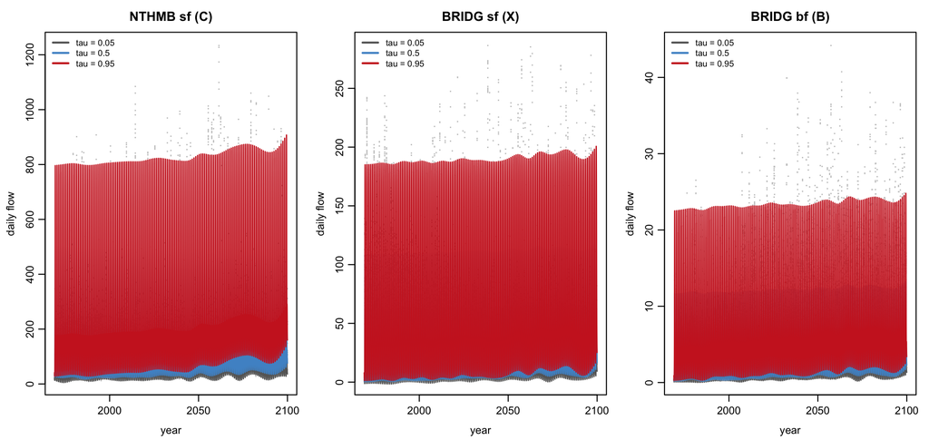

```r
op <- par(mfrow = c(1, 3), mar = c(3.5, 3.5, 2.5, 1), mgp = c(2.2, 0.7, 0))
show <- c(which.min(abs(taus - 0.05)), which.min(abs(taus - 0.5)), K)
lcol <- c("grey40", "steelblue3", "firebrick3")
for (s in list(list(xC, mC, "NTHMB sf (C)"), list(xX, mX, "BRIDG sf (X)"),
               list(xB, mB, "BRIDG bf (B)"))) {
  plot(dates, s[[1]], pch = ".", col = "grey80", xlab = "year",
       ylab = "daily flow", main = s[[3]])
  for (j in seq_along(show))
    lines(dates, s[[2]]$U[, show[j]], lwd = 1.2, col = lcol[j])
  legend("topleft", paste0("tau = ", taus[show]), col = lcol, lwd = 2,
         bty = "n", cex = 0.8)
}
```

```r
par(op)
```

**Reading the figure.** One panel per series; x-axis calendar time, y-axis daily flow, grey dots the raw series. The curves are three rungs of the ladder: $\tau = 0.05$ (lower envelope), $\tau = 0.5$ (the moving median — the closest analogue of a location curve $\mu(t)$ in this threshold-based route), and $\tau^{*} = 0.95$, the working threshold: the GP tail is fitted to overshoots above the red curve. Unlike a trend-only fit, these curves now oscillate within each year — the seasonal cycle — while their year-to-year drift carries the climate signal. At this compression the seasonal band looks solid; the next figure zooms in.

```r
xCbf <- get_series(C_st, "bf")
mCbf <- fit_ladder_cached(xCbf, "Cbf")   # NTHMB baseflow ladder (one-time fit)
```

```
## ladder Cbf loaded from cache: cache_ladder_Cbf_qgam_47847_75454.rds
```

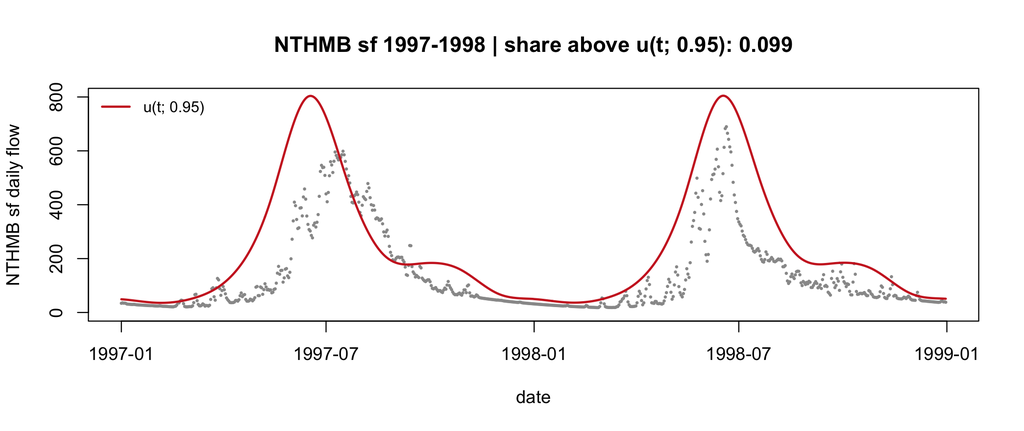

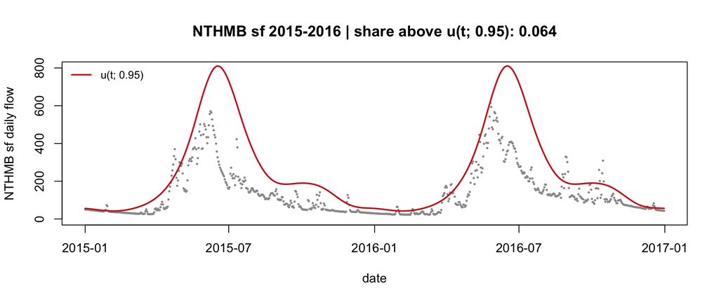

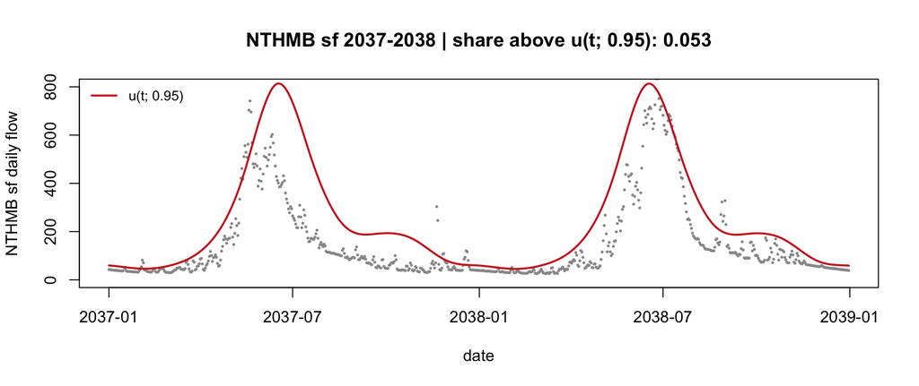

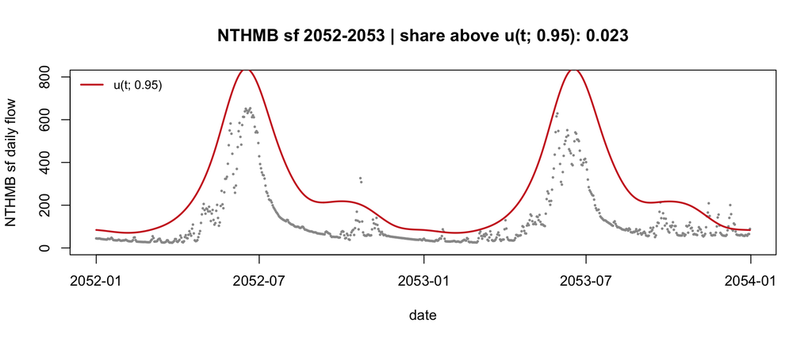

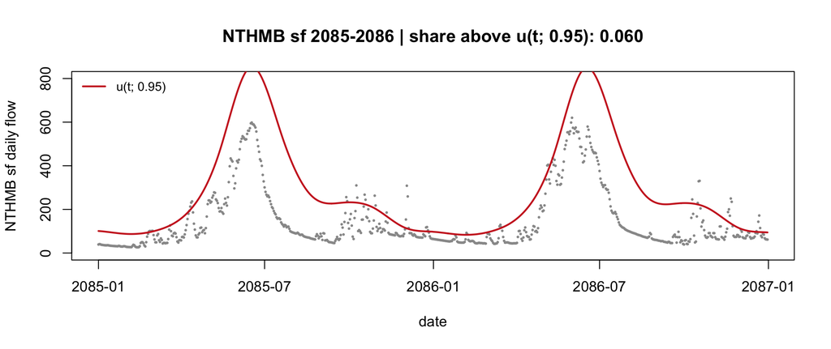

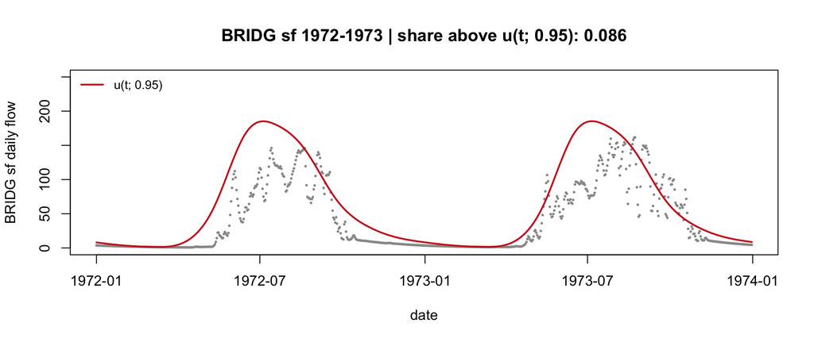

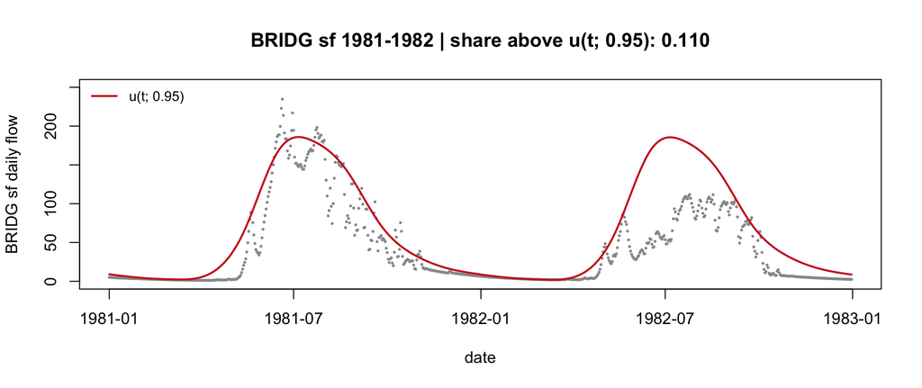

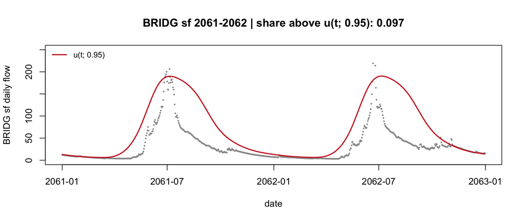

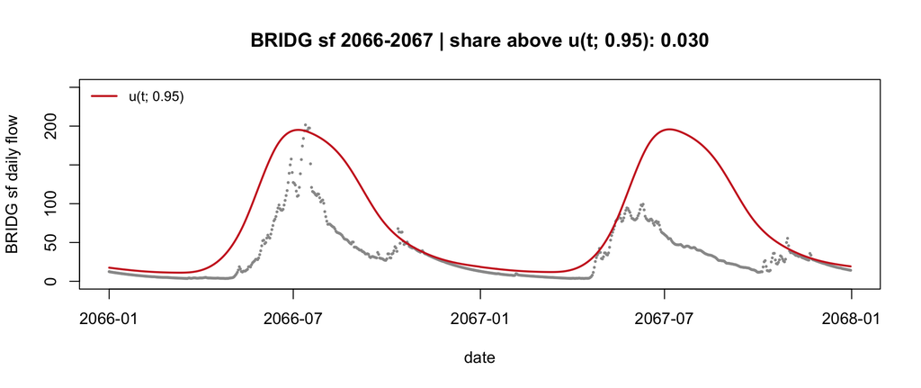

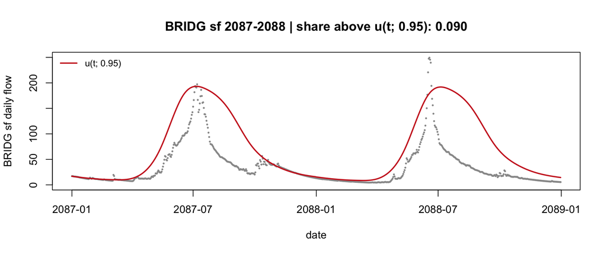

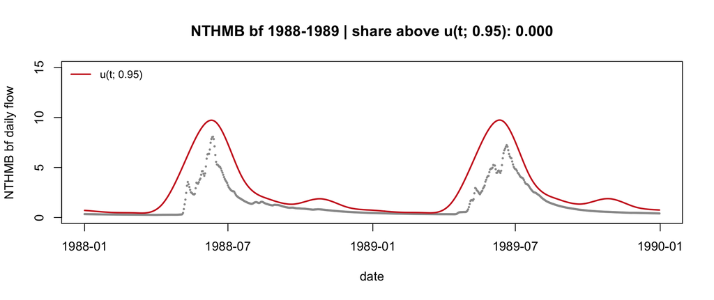

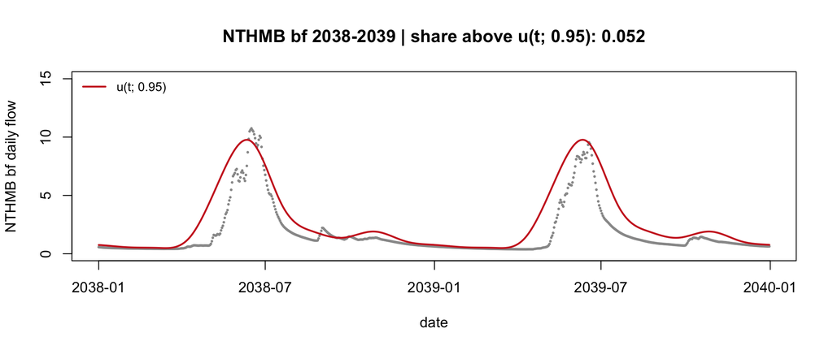

[8 more figures not shown]

```r
# Add the specific y-limits as the 4th element in each list
ser4 <- list(list(xC, mC, "NTHMB sf", c(0, 800)),
             list(xX, mX, "BRIDG sf", c(0, 250)),
             list(xCbf, mCbf, "NTHMB bf", c(0, 15)),
             list(xB, mB, "BRIDG bf", c(0, 30)))

set.seed(62)                               # reproducible window draw
for (s in ser4) {

  # Extract the hardcoded custom ylim for this specific series
  y_limits <- s[[4]]

  for (zy in sort(sample(min(years):(max(years) - 1), 5))) {
    k <- years %in% c(zy, zy + 1)
    sh <- mean(s[[1]][k] > s[[2]]$U[k, K])

    # Use the extracted y_limits
    plot(dates[k], s[[1]][k], pch = 16, cex = 0.4, col = "grey60",
         xlab = "date", ylab = paste(s[[3]], "daily flow"),
         ylim = y_limits,
         main = sprintf("%s %d-%d | share above u(t; %.2f): %.3f",
                        s[[3]], zy, zy + 1, params$tau_star, sh))

    # Only plot the target threshold line
    lines(dates[k], s[[2]]$U[k, K], lwd = 2, col = "firebrick3")

    # Updated legend (removed median rung)
    legend("topleft", sprintf("u(t; %.2f)", params$tau_star),
           lwd = 2, col = "firebrick3", bty = "n", cex = 0.85)
  }
}
```

## 3.2 Local exceedance proportions (the “5% locally” check)

```r
seas_of <- function(m) c("DJF","DJF","MAM","MAM","MAM","JJA",
                         "JJA","JJA","SON","SON","SON","DJF")[m]
seas <- seas_of(months)
era <- cut(years, breaks = seq(min(years), max(years) + 22, by = 22),
           right = FALSE, dig.lab = 4)
excX <- xX > mX$U[, K]
tab <- round(tapply(excX, list(seas, era), mean), 3)
knitr::kable(tab, caption = sprintf("BRIDG: share of days above u(t; %.2f)
by season and era. Target %.2f in every cell -- locally, not just pooled
(meeting 62). A cell far below target says the threshold missed that
season's level in that era.", params$tau_star, 1 - params$tau_star))
```

BRIDG: share of days above u(t; 0.95) by season and era. Target 0.05 in every cell – locally, not just pooled (meeting 62). A cell far below target says the threshold missed that season’s level in that era.

|  | [1969,1991) | [1991,2013) | [2013,2035) | [2035,2057) | [2057,2079) | [2079,2101) |
| --- | --- | --- | --- | --- | --- | --- |
| DJF | 0.010 | 0.032 | 0.046 | 0.046 | 0.045 | 0.064 |
| JJA | 0.123 | 0.031 | 0.016 | 0.036 | 0.026 | 0.037 |
| MAM | 0.074 | 0.048 | 0.072 | 0.026 | 0.032 | 0.030 |
| SON | 0.149 | 0.040 | 0.020 | 0.016 | 0.046 | 0.057 |

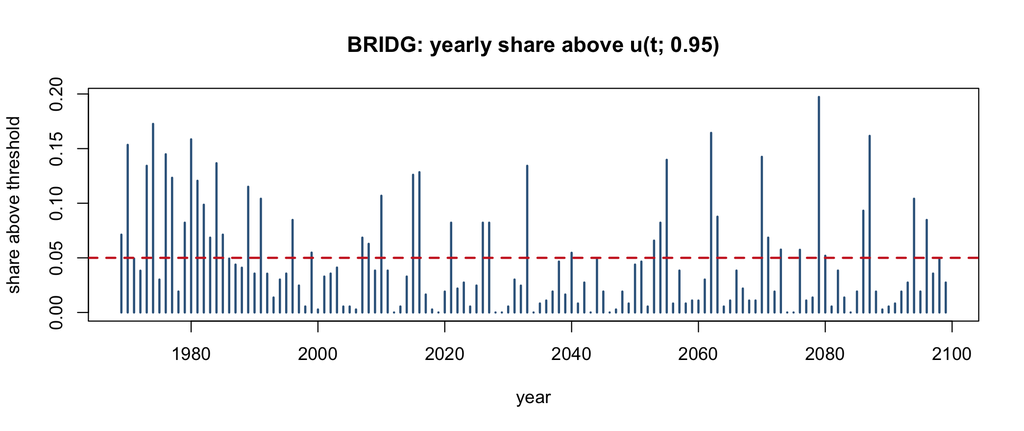

```r
sh <- sapply(yrs_u, function(y) mean(excX[years == y]))
plot(yrs_u, sh, type = "h", lwd = 2, col = "steelblue4",
     xlab = "year", ylab = "share above threshold",
     main = sprintf("BRIDG: yearly share above u(t; %.2f)", params$tau_star))
abline(h = 1 - params$tau_star, col = "firebrick3", lwd = 2, lty = 2)
```

**Reading the figure and table.** Table: rows are seasons, columns eras; each cell the share of that season-era’s days above the working threshold. The design target is 0.05 everywhere — the moving threshold’s defining property (v8 3, p. 4), now demanded per season as well as per era. Figure: the same share per calendar year against the dashed target line; wandering above and below is sampling noise, a sustained drift is a threshold failure. This is also qgam’s own recommended bias check for its smoothed loss — one table serves both purposes. If the cells miss the target in a season-by-era *pattern* — one season too low early and too high late — the additive design (one seasonal shape shared by every year, plus a trend) is too rigid, and the next design step is the tensor interaction `te(doy, tt)`: the seasonal shape itself allowed to drift, which the qgam route fits with one formula change.

```r
if (has["qgam"]) {
  f_te <- sprintf("cache_uX_te_qgam_%d_%.0f.rds", N, sum(xX))
  u_te <- tryCatch({
    if (!params$refit_ladders && file.exists(f_te)) readRDS(f_te) else {
      d <- data.frame(y = xX, tt = tt, doy = doy)
      fm <- list(y ~ te(doy, tt, bs = c("cc", "cr"), k = c(10, 15)),
                 ~ s(doy, bs = "cc", k = 8))
      kn <- list(knots = list(doy = c(0.5, 366.5)))
      fte <- qgam(fm, data = d, qu = params$tau_star, argGam = kn)
      u1 <- as.numeric(predict(fte, newdata = d))
      saveRDS(u1, f_te); u1
    }
  }, error = function(e) {
    cat("NOTE: te branch failed (", conditionMessage(e), ")\n", sep = ""); NULL })
  if (!is.null(u_te)) {
    tab_te <- round(tapply(xX > u_te, list(seas, era), mean), 3)
    knitr::kable(tab_te, caption = "BRIDG, tensor te(doy, tt) threshold at
    0.95: the season x era exceedance table again. If the additive design's
    first-era misses (SON 0.149, JJA 0.123, DJF 0.010) shrink toward 0.05
    here, the seasonal shape itself drifts across the century and the
    tensor becomes the production design.")
  }
} else cat("qgam absent in this environment - te experiment skipped\n")
```

BRIDG, tensor te(doy, tt) threshold at 0.95: the season x era exceedance table again. If the additive design’s first-era misses (SON 0.149, JJA 0.123, DJF 0.010) shrink toward 0.05 here, the seasonal shape itself drifts across the century and the tensor becomes the production design.

|  | [1969,1991) | [1991,2013) | [2013,2035) | [2035,2057) | [2057,2079) | [2079,2101) |
| --- | --- | --- | --- | --- | --- | --- |
| DJF | 0.012 | 0.053 | 0.042 | 0.037 | 0.027 | 0.042 |
| JJA | 0.039 | 0.046 | 0.036 | 0.052 | 0.047 | 0.053 |
| MAM | 0.043 | 0.043 | 0.051 | 0.029 | 0.029 | 0.038 |
| SON | 0.039 | 0.039 | 0.051 | 0.034 | 0.037 | 0.053 |

## 3.3 Move one at the threshold (v8 4.6, p. 10)

```r
thr_move1 <- function(x, B = 30) {
  Xlin <- cbind(1, tt, H)
  sl <- rq.fit.fnb(Xlin, x, tau = params$tau_star)$coefficients[2]
  yrs <- unique(years)
  reps <- replicate(B, {
    keep <- years %in% sample(yrs, replace = TRUE)
    rq.fit.fnb(Xlin[keep, ], x[keep], tau = params$tau_star)$coefficients[2]
  })
  c(slope_tt = sl, se = sd(reps), z = sl / sd(reps))
}
knitr::kable(round(rbind(`NTHMB sf` = thr_move1(xC), `BRIDG sf` = thr_move1(xX),
                         `BRIDG bf` = thr_move1(xB)), 3),
             caption = "Move one at the threshold: the trend slope of the
             linear-in-t rung (seasonal harmonics included in both models,
             so the slope is the trend, not the seasons) against its
             year-block bootstrap SE. A constant winning is a legitimate
             outcome (v8 Sec 4.6, p. 10).")
```

Move one at the threshold: the trend slope of the linear-in-t rung (seasonal harmonics included in both models, so the slope is the trend, not the seasons) against its year-block bootstrap SE. A constant winning is a legitimate outcome (v8 Sec 4.6, p. 10).

|  | slope_tt.tt | se | z.tt |
| --- | --- | --- | --- |
| NTHMB sf | 61.811 | 5.239 | 11.797 |
| BRIDG sf | 7.124 | 1.022 | 6.970 |
| BRIDG bf | 1.767 | 0.100 | 17.673 |

# 4 Stage 1b: GP tail (v8 2.2, eq. 4, p. 3)

The scale $\sigma(t)$ gets the same seasonal + trend structure as the threshold — with a seasonal threshold, winter exceedances exist and their overshoots are far smaller than freshet overshoots, so a seasonal scale is not optional. The shape $\xi$ stays constant per series (decided; v8 2.2, p. 3) and is printed — the number to quote when asked. Production route: evgam (`family = "gpd"`, REML smoothing); fallback + check: the project penalized likelihood on the seasonal + trend design.

```r
gp_nll <- function(par, y, Xg, lambda = 0, Dg = NULL) {
  pg <- ncol(Xg)
  gam <- par[1:pg]; xi <- par[pg + 1]
  sig <- exp(as.vector(Xg %*% gam))
  z <- 1 + xi * y / sig
  if (any(z <= 0)) return(1e10)
  nll <- sum(log(sig) + (1 + 1 / xi) * log(z))
  if (!is.null(Dg) && lambda > 0) nll <- nll + lambda * sum((Dg %*% gam)^2)
  nll
}
fit_gp_basis <- function(y, Xg, lambda = 0, Dg = NULL) {
  init <- c(log(mean(y)), rep(0, ncol(Xg) - 1), 0.05)
  o <- optim(init, gp_nll, y = y, Xg = Xg, lambda = lambda, Dg = Dg,
             method = "BFGS", control = list(maxit = 600))
  list(gam = o$par[1:ncol(Xg)], xi = o$par[ncol(Xg) + 1], nll = o$value)
}

fit_gp_own <- function(x, ladder) {
  u <- ladder$U[, K]; exc <- x > u
  y <- (x - u)[exc]
  Xg  <- cbind(Btrend, H)[exc, , drop = FALSE]
  fe <- folds[exc]
  ## move one: harmonics in both, trend column the difference
  f0 <- fit_gp_basis(y, cbind(1, H[exc, , drop = FALSE]))
  f1 <- fit_gp_basis(y, cbind(1, tt[exc], H[exc, , drop = FALSE]))
  LRT <- 2 * (f0$nll - f1$nll)
  cvs <- sapply(lam_grid, function(lam) {
    mean(sapply(sort(unique(fe)), function(k) {
      tr <- fe != k
      f <- fit_gp_basis(y[tr], Xg[tr, , drop = FALSE], lam, Dtr)
      gp_nll(c(f$gam, f$xi), y[!tr], Xg[!tr, , drop = FALSE]) / sum(!tr)
    }))
  })
  lam_s <- lam_grid[which.min(cvs)]
  fs <- fit_gp_basis(y, Xg, lam_s, Dtr)
  sig <- exp(as.vector(cbind(Btrend, H) %*% fs$gam))
  list(exc = exc, u = u, n_exc = sum(exc), const = f0, lin = f1,
       LRT = LRT, p = 1 - pchisq(LRT, 1), lam_s = lam_s,
       sig = sig, xi = fs$xi, route = "own")
}

fit_gp_evgam <- function(x, ladder) {
  tryCatch({
    u <- ladder$U[, K]; exc <- x > u
    d <- data.frame(y = (x - u)[exc], tt = tt[exc], doy = doy[exc])
    f <- evgam::evgam(list(y ~ s(doy, bs = "cc", k = 8) + s(tt, k = 15), ~ 1),
                      data = d, family = "gpd",
                      knots = list(doy = c(0.5, 366.5)))
    pr <- predict(f, newdata = data.frame(tt = tt, doy = doy),
                  type = "response")
    sig <- as.numeric(pr[[1]]); xi <- as.numeric(pr[[2]][1])
    own <- fit_gp_own(x, ladder)
    gapc <- max(abs(sig - own$sig) / own$sig)
    cat(sprintf("evgam vs project sigma(t): max relative gap %.3f (REML vs
    CV smoothing; reported, not asserted)\n", gapc))
    out <- own
    out$sig <- sig; out$xi <- xi; out$route <- "evgam"
    out
  }, error = function(e) {
    cat("NOTE: evgam branch failed (", conditionMessage(e),
        ") - project fallback used\n", sep = "")
    fit_gp_own(x, ladder)
  })
}
fit_gp_stage <- function(x, ladder)
  if (has["evgam"]) fit_gp_evgam(x, ladder) else fit_gp_own(x, ladder)
```

```r
gC <- fit_gp_stage(xC, mC); gX <- fit_gp_stage(xX, mX); gB <- fit_gp_stage(xB, mB)
```

```
## evgam vs project sigma(t): max relative gap 0.185 (REML vs
##     CV smoothing; reported, not asserted)
```

```
## evgam vs project sigma(t): max relative gap 0.363 (REML vs
##     CV smoothing; reported, not asserted)
```

```
## evgam vs project sigma(t): max relative gap 1.010 (REML vs
##     CV smoothing; reported, not asserted)
```

```r
knitr::kable(data.frame(
  series = c("NTHMB sf", "BRIDG sf", "BRIDG bf"),
  route = c(gC$route, gX$route, gB$route),
  n_exc = c(gC$n_exc, gX$n_exc, gB$n_exc),
  xi = round(c(gC$xi, gX$xi, gB$xi), 3),
  LRT_trend = round(c(gC$LRT, gX$LRT, gB$LRT), 2),
  p_value = signif(c(gC$p, gX$p, gB$p), 2)),
  caption = "GP stage: route actually used, exceedance count, the constant
  shape xi (the number to quote), and move one for the trend in log sigma
  (LRT vs chi-squared(1), harmonics in both candidates).")
```

GP stage: route actually used, exceedance count, the constant shape xi (the number to quote), and move one for the trend in log sigma (LRT vs chi-squared(1), harmonics in both candidates).

| series | route | n_exc | xi | LRT_trend | p_value |
| --- | --- | --- | --- | --- | --- |
| NTHMB sf | evgam | 2264 | 0.038 | 108.17 | 0 |
| BRIDG sf | evgam | 2236 | 0.118 | 35.45 | 0 |
| BRIDG bf | evgam | 2299 | -0.058 | 89.27 | 0 |

```r
## sigma(t) in chunks -- the meeting's 'look at the scale in smaller pieces'
sig_tab <- round(rbind(
  `NTHMB sf` = tapply(gC$sig, list(era), mean),
  `BRIDG sf` = tapply(gX$sig, list(era), mean),
  `BRIDG bf` = tapply(gB$sig, list(era), mean)), 2)
knitr::kable(sig_tab, caption = "Mean fitted GP scale sigma(t) by era: the
chunked view of the scale curve. Read along a row for the trend in typical
overshoot size.")
```

Mean fitted GP scale sigma(t) by era: the chunked view of the scale curve. Read along a row for the trend in typical overshoot size.

|  | [1969,1991) | [1991,2013) | [2013,2035) | [2035,2057) | [2057,2079) | [2079,2101) |
| --- | --- | --- | --- | --- | --- | --- |
| NTHMB sf | 28.96 | 33.93 | 39.75 | 46.56 | 54.56 | 63.70 |
| BRIDG sf | 8.54 | 7.23 | 9.35 | 12.04 | 13.84 | 11.95 |
| BRIDG bf | 0.73 | 1.34 | 1.24 | 1.49 | 2.09 | 1.72 |

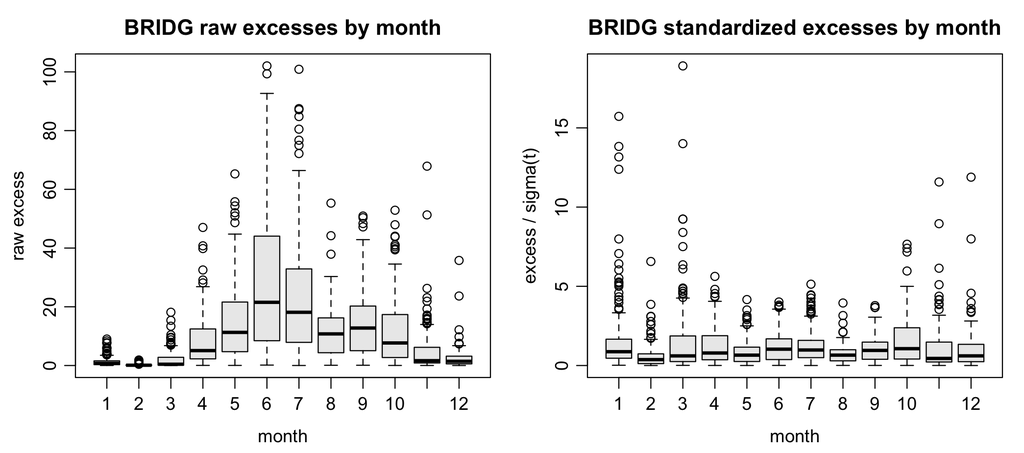

```r
op <- par(mfrow = c(1, 2), mar = c(3.5, 3.5, 2.5, 1), mgp = c(2.2, 0.7, 0))
excd <- xX > mX$U[, K]
boxplot((xX - mX$U[, K])[excd] ~ months[excd], col = "grey92",
        xlab = "month", ylab = "raw excess",
        main = "BRIDG raw excesses by month")
boxplot(((xX - mX$U[, K]) / gX$sig)[excd] ~ months[excd], col = "grey92",
        xlab = "month", ylab = "excess / sigma(t)",
        main = "BRIDG standardized excesses by month")
```

```r
par(op)
```

**Reading the figure.** Left: the raw overshoots above the threshold, by calendar month of occurrence — with a seasonal threshold there are exceedance days in every month, and their raw sizes may legitimately differ by season (freshet overshoots are physically larger). Right: the same excesses divided by the fitted seasonal $\sigma(t)$ — if the scale model has absorbed the seasonality, these boxes should be level across months with no drift; a remaining monthly pattern here is the meeting’s “excesses still seasonal” failure, localized to the GP stage rather than the threshold.

```r
gp_seas <- do.call(rbind, lapply(c("DJF", "MAM", "JJA", "SON"), function(sn) {
  e <- excd & seas == sn
  y <- ((xX - mX$U[, K]) / gX$sig)[e]
  f <- fit_gp_basis(y, matrix(1, sum(e), 1))
  data.frame(season = sn, n = sum(e), sigma_std = round(exp(f$gam[1]), 3),
             xi = round(f$xi, 3))
}))
knitr::kable(gp_seas, row.names = FALSE, caption = sprintf("Per-season GP on
sigma(t)-standardized BRIDG excesses. If the seasonal scale model is right,
sigma_std sits near 1 in every row. The xi column probes the constant-shape
decision (pooled xi = %.3f): a DJF value far above the others is the heavy
winter tail the Exp(1) panels showed, and the case to discuss before ever
freeing xi.", gX$xi))
```

Per-season GP on sigma(t)-standardized BRIDG excesses. If the seasonal scale model is right, sigma_std sits near 1 in every row. The xi column probes the constant-shape decision (pooled xi = 0.118): a DJF value far above the others is the heavy winter tail the Exp(1) panels showed, and the case to discuss before ever freeing xi.

| season | n | sigma_std | xi |
| --- | --- | --- | --- |
| DJF | 478 | 0.827 | 0.271 |
| MAM | 568 | 0.944 | 0.193 |
| JJA | 538 | 1.301 | -0.180 |
| SON | 652 | 1.073 | 0.051 |

# 5 Stage 1c: transform to Laplace, and the gates (v8 3, eqs. 5–6, pp. 3–4)

The two fitted pieces assemble into $F(x;t)$ — ladder interpolation in the body, GP tail above $u(t;\tau^{*})$ (v8 eq. 5, p. 3) — and each day’s value maps through its own day’s $F$ to the standard Laplace scale (v8 eq. 6, p. 4; Keef et al. 2013 eq. 2.1). Below the bottom rung ($\tau = 0.01$) the lower tail decays exponentially, matched continuously to the bottom ladder segment; the numerical floor sits at $1/(4N)$ and the count of days reaching it is printed — the old transform’s hard clamp at $10^{-5}$, which collapsed the lowest days onto the single value $-2.44$ and drew the flat-then-jump QQ artifact, is gone, and this instrumentation proves it on every knit.

```r
qlap <- function(p) ifelse(p < 0.5, log(2 * p), -log(2 * (1 - p)))
plap <- function(y) ifelse(y < 0, exp(y) / 2, 1 - exp(-y) / 2)

F_of <- function(x, ladder, gp) {
  U <- ladder$U
  Fv <- rep(NA_real_, length(x))
  above <- x > U[, K]
  S <- (1 + gp$xi * (x - U[, K]) / gp$sig)
  Fv[above] <- 1 - (1 - params$tau_star) * pmax(S[above], 0)^(-1 / gp$xi)
  for (k in seq_len(K - 1)) {
    m <- !above & x > U[, k] & x <= U[, k + 1]
    Fv[m] <- taus[k] + (taus[k + 1] - taus[k]) *
             (x[m] - U[m, k]) / (U[m, k + 1] - U[m, k])
  }
  low <- !above & x <= U[, 1]
  beta1 <- (U[, 2] - U[, 1]) / log(taus[2] / taus[1])   # continuous match
  Fv[low] <- taus[1] * exp((x[low] - U[low, 1]) / beta1[low])
  n_low <- sum(low); n_floor <- sum(Fv[low] <= 1 / (4 * N))
  cat(sprintf("  below bottom rung: %d days (%.2f%%); at numerical floor: %d\n",
      n_low, 100 * n_low / length(x), n_floor))
  pmin(pmax(Fv, 1 / (4 * N)), 1 - 1e-9)
}
cat("NTHMB sf:\n"); FC <- F_of(xC, mC, gC)
```

```
## NTHMB sf:
```

```
##   below bottom rung: 193 days (0.40%); at numerical floor: 0
```

```r
cat("BRIDG sf:\n"); FX <- F_of(xX, mX, gX)
```

```
## BRIDG sf:
```

```
##   below bottom rung: 220 days (0.46%); at numerical floor: 0
```

```r
cat("BRIDG bf:\n"); FB <- F_of(xB, mB, gB)
```

```
## BRIDG bf:
```

```
##   below bottom rung: 254 days (0.53%); at numerical floor: 0
```

```r
YC <- qlap(FC); YX <- qlap(FX); YB <- qlap(FB)
y_star <- -log(2 * (1 - params$tau_star))    # 2.303 at 0.95 (v8 Sec 3, p. 4)
```

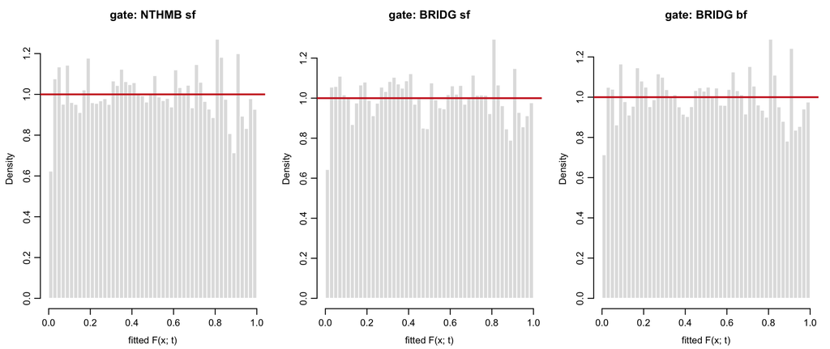

```r
op <- par(mfrow = c(1, 3), mar = c(3.5, 3.5, 2.5, 1), mgp = c(2.2, 0.7, 0))
for (nm in c("FC", "FX", "FB")) {
  hist(get(nm), breaks = 40, col = "grey88", border = "white", freq = FALSE,
       xlab = "fitted F(x; t)", main = paste("gate:",
       c(FC = "NTHMB sf", FX = "BRIDG sf", FB = "BRIDG bf")[nm]))
  abline(h = 1, col = "firebrick3", lwd = 2)
}
```

```r
par(op)
```

**Reading the figure.** The gate of stage 1 (v8 3, p. 4). The x-axis is each day’s fitted probability under its own day’s distribution; the y-axis density. If the marginal model is right these are Unif(0,1): flat bars on the red line. A spike in the first bar was the old clamp’s signature; a bump near 1 says the tail is too light; waves in the body point at the ladder; and — the meeting’s verdict on the previous version — a shape that reappears when sliced by season is the seasonality the margins missed, which the seasonal basis exists to remove. Downstream stages wait here.

```r
rung_audit <- function(x, ladder)
  sapply(seq_len(K), function(k) mean(x <= ladder$U[, k]) - taus[k])
ra <- round(rbind(`NTHMB sf` = rung_audit(xC, mC),
                  `BRIDG sf` = rung_audit(xX, mX),
                  `BRIDG bf` = rung_audit(xB, mB)), 4)
colnames(ra) <- paste0("tau=", taus)
knitr::kable(ra, caption = "Rung calibration audit: share of days at or
below each fitted rung, minus its target tau. Zero everywhere = a
perfectly calibrated ladder. A negative entry at tau = 0.01 means the
bottom rung sits too low (the short first histogram bar); an entry off
zero at an interior rung places a histogram wave at that rung of the
qgam fit.")
```

Rung calibration audit: share of days at or below each fitted rung, minus its target tau. Zero everywhere = a perfectly calibrated ladder. A negative entry at tau = 0.01 means the bottom rung sits too low (the short first histogram bar); an entry off zero at an interior rung places a histogram wave at that rung of the qgam fit.

|  | tau=0.01 | tau=0.025 | tau=0.05 | tau=0.1 | tau=0.2 | tau=0.3 | tau=0.4 | tau=0.5 | tau=0.6 | tau=0.7 | tau=0.8 | tau=0.9 | tau=0.95 |
| --- | --- | --- | --- | --- | --- | --- | --- | --- | --- | --- | --- | --- | --- |
| NTHMB sf | -0.0060 | -0.0063 | -0.0036 | -0.0014 | -0.0009 | -0.0047 | 0.0022 | 0.0026 | 0.0019 | 0.0046 | 0.0044 | 0.0034 | 0.0027 |
| BRIDG sf | -0.0054 | -0.0057 | -0.0041 | -0.0023 | -0.0024 | -0.0031 | 0.0049 | 0.0006 | 0.0003 | 0.0027 | 0.0043 | 0.0035 | 0.0033 |
| BRIDG bf | -0.0047 | -0.0037 | -0.0029 | -0.0034 | -0.0020 | 0.0022 | 0.0005 | -0.0002 | 0.0001 | 0.0026 | 0.0027 | 0.0030 | 0.0020 |

```r
ra_era <- sapply(seq_len(K), function(k)
  tapply(xX <= mX$U[, k], era, mean) - taus[k])
colnames(ra_era) <- paste0("tau=", taus)
knitr::kable(round(ra_era, 3), caption = "BRIDG sf: the same audit per era
-- an entry that changes sign along a row is drift the additive seasonal
basis missed (the te case), not a global rung offset.")
```

BRIDG sf: the same audit per era – an entry that changes sign along a row is drift the additive seasonal basis missed (the te case), not a global rung offset.

|  | tau=0.01 | tau=0.025 | tau=0.05 | tau=0.1 | tau=0.2 | tau=0.3 | tau=0.4 | tau=0.5 | tau=0.6 | tau=0.7 | tau=0.8 | tau=0.9 | tau=0.95 |
| --- | --- | --- | --- | --- | --- | --- | --- | --- | --- | --- | --- | --- | --- |
| [1969,1991) | -0.003 | 0.007 | 0.016 | 0.024 | 0.018 | -0.001 | -0.013 | -0.029 | -0.040 | -0.058 | -0.071 | -0.062 | -0.039 |
| [1991,2013) | -0.007 | -0.012 | -0.016 | -0.015 | -0.036 | -0.042 | -0.039 | -0.058 | -0.069 | -0.068 | -0.034 | 0.003 | 0.012 |
| [2013,2035) | -0.007 | -0.013 | -0.018 | -0.021 | -0.042 | -0.051 | -0.056 | -0.048 | -0.025 | 0.009 | 0.028 | 0.023 | 0.011 |
| [2035,2057) | -0.009 | -0.016 | -0.024 | -0.041 | -0.032 | -0.029 | -0.004 | 0.019 | 0.037 | 0.058 | 0.046 | 0.021 | 0.019 |
| [2057,2079) | 0.001 | 0.007 | 0.018 | 0.025 | 0.044 | 0.062 | 0.083 | 0.074 | 0.058 | 0.043 | 0.029 | 0.021 | 0.013 |
| [2079,2101) | -0.008 | -0.008 | -0.001 | 0.014 | 0.035 | 0.045 | 0.062 | 0.048 | 0.043 | 0.033 | 0.029 | 0.014 | 0.003 |

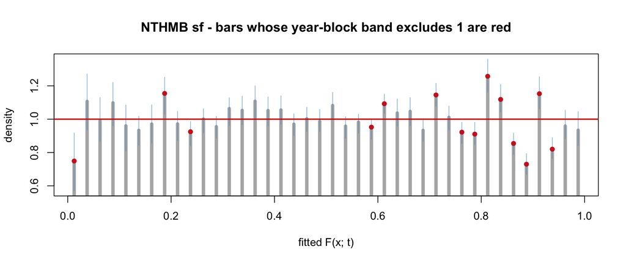

```
## NTHMB sf - genuinely off bins at: 0.013 0.188 0.237 0.588 0.613 0.713 0.763 0.788 0.813 0.838 0.863 0.888 0.913 0.938
```

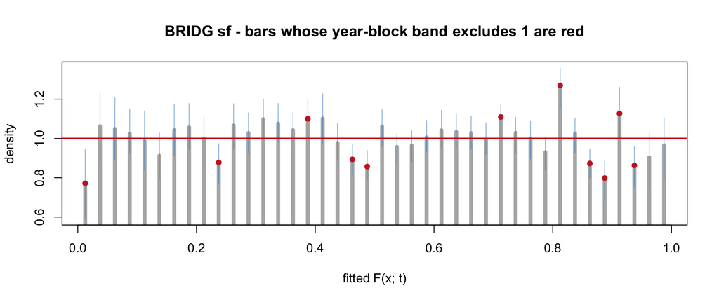

```
## BRIDG sf - genuinely off bins at: 0.013 0.237 0.388 0.463 0.487 0.713 0.813 0.863 0.888 0.913 0.938
```

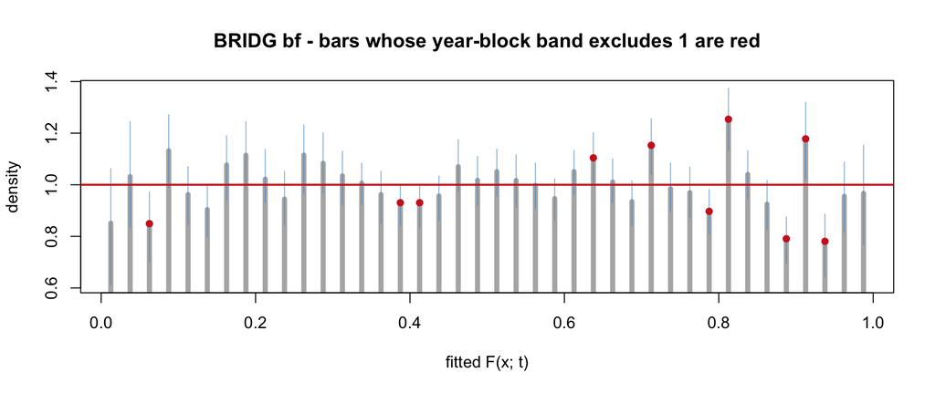

```
## BRIDG bf - genuinely off bins at: 0.063 0.388 0.413 0.638 0.713 0.788 0.813 0.888 0.913 0.938
```

```r
brks <- seq(0, 1, by = 0.025); mids <- brks[-1] - 0.0125
for (nm in c("FC", "FX", "FB")) {
  Fv <- get(nm); lab <- c(FC = "NTHMB sf", FX = "BRIDG sf", FB = "BRIDG bf")[nm]
  dens <- hist(Fv, breaks = brks, plot = FALSE)$density
  bootd <- replicate(200, {
    ky <- years %in% sample(unique(years), replace = TRUE)
    hist(Fv[ky], breaks = brks, plot = FALSE)$density
  })
  bb <- apply(bootd, 1, quantile, c(0.025, 0.975))
  bad <- which(bb[1, ] > 1 | bb[2, ] < 1)
  plot(mids, dens, type = "h", lwd = 5, col = "grey70",
       ylim = range(bb, dens, 1), xlab = "fitted F(x; t)", ylab = "density",
       main = paste(lab, "- bars whose year-block band excludes 1 are red"))
  segments(mids, bb[1, ], mids, bb[2, ], col = adjustcolor("steelblue3", 0.6))
  abline(h = 1, col = "firebrick3", lwd = 2)
  points(mids[bad], dens[bad], pch = 16, col = "firebrick3")
  cat(lab, "- genuinely off bins at:",
      paste(sprintf("%.3f", mids[bad]), collapse = " "), "\n")
}
```

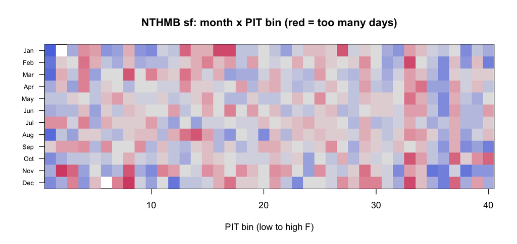

```
## NTHMB sf: month x PIT bin (red = too many days) | largest cell: Jan bin (0.025, 0.050], residual +7.1
```

```r
comp_map <- function(Fv, fac, main) {
  nb <- length(brks) - 1
  Ocnt <- table(fac, cut(Fv, brks, include.lowest = TRUE))
  Ecnt <- rowSums(Ocnt) %o% rep(1 / nb, nb)
  R <- (Ocnt - Ecnt) / sqrt(Ecnt)          # chi-square-style cell residuals
  image(1:nb, 1:nrow(R), t(R[nrow(R):1, ]), zlim = c(-6, 6),
        col = hcl.colors(25, "Blue-Red 2"), xlab = "PIT bin (low to high F)",
        ylab = "", yaxt = "n", main = main)
  axis(2, at = 1:nrow(R), labels = rev(rownames(R)), las = 2, cex.axis = 0.7)
  wr <- which(abs(R) == max(abs(R)), arr.ind = TRUE)[1, ]
  cat(main, "| largest cell:", rownames(R)[wr[1]],
      sprintf("bin (%.3f, %.3f], residual %+.1f\n",
              brks[wr[2]], brks[wr[2] + 1], R[wr[1], wr[2]]))
}
mon <- factor(month.abb[months], levels = month.abb)
comp_map(FC, mon, "NTHMB sf: month x PIT bin (red = too many days)")
```

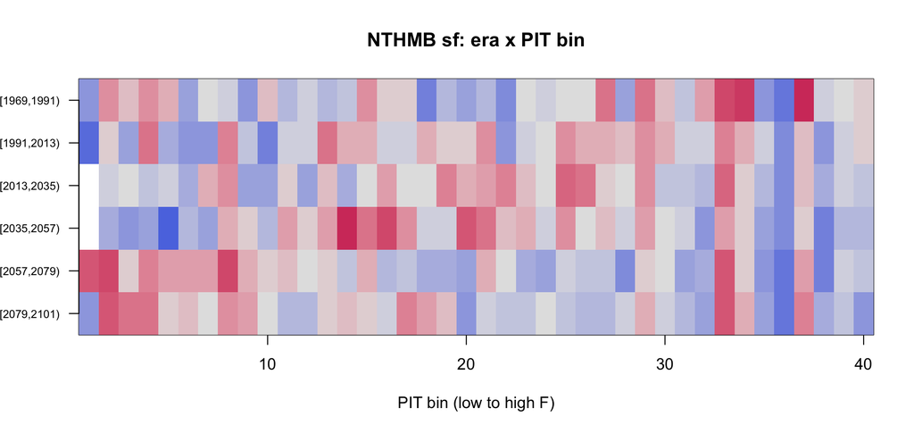

```
## NTHMB sf: era x PIT bin | largest cell: [2013,2035) bin (0.000, 0.025], residual -7.5
```

```r
comp_map(FC, era, "NTHMB sf: era x PIT bin")
```

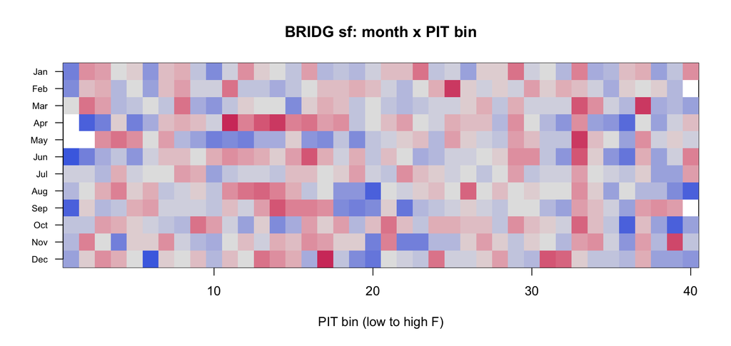

```
## BRIDG sf: month x PIT bin | largest cell: Apr bin (0.000, 0.025], residual -8.9
```

```r
comp_map(FX, mon, "BRIDG sf: month x PIT bin")
```

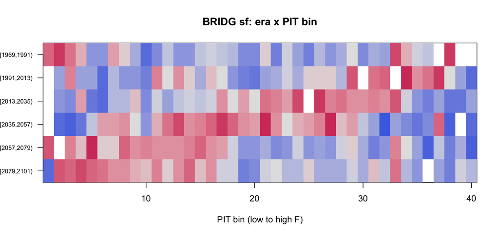

```
## BRIDG sf: era x PIT bin | largest cell: [1969,1991) bin (0.975, 1.000], residual +15.2
```

```r
comp_map(FX, era, "BRIDG sf: era x PIT bin")
```

## 5.1 Pooled and sliced Laplace QQ (v8 3, p. 4)

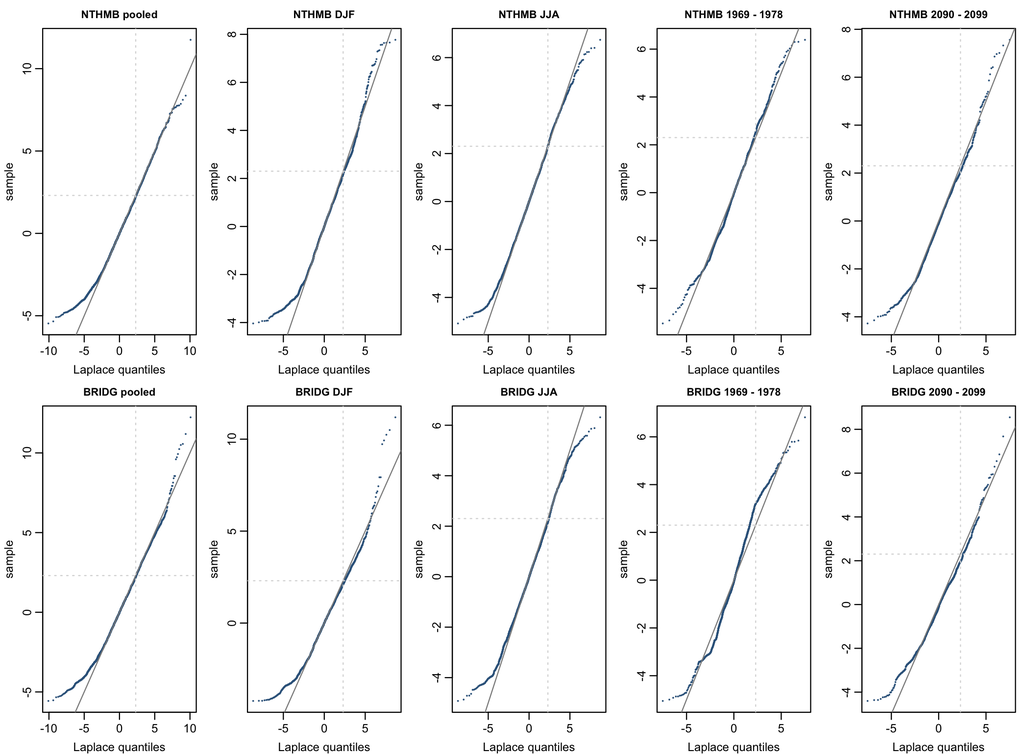

```r
qq_laplace <- function(y, main) {
  n <- length(y); th <- qlap((1:n) / (n + 1))
  plot(th, sort(y), pch = 16, cex = 0.35, col = "steelblue4",
       xlab = "Laplace quantiles", ylab = "sample", main = main,
       cex.main = 0.9)
  abline(0, 1, col = "grey55"); abline(h = y_star, v = y_star,
                                       col = "grey85", lty = 3)
}
dec1 <- min(years):(min(years) + 9)
dec2 <- (max(years) - 9):max(years)
op <- par(mfrow = c(2, 5), mar = c(3, 3, 2, 0.6), mgp = c(1.9, 0.6, 0))
for (yv in list(c("YC", "NTHMB"), c("YX", "BRIDG"))) {
  Y <- get(yv[1])
  qq_laplace(Y, paste(yv[2], "pooled"))
  qq_laplace(Y[seas == "DJF"], paste(yv[2], "DJF"))
  qq_laplace(Y[seas == "JJA"], paste(yv[2], "JJA"))
  qq_laplace(Y[years %in% dec1], paste(yv[2], min(dec1), "-", max(dec1)))
  qq_laplace(Y[years %in% dec2], paste(yv[2], min(dec2), "-", max(dec2)))
}
```

```r
par(op)
```

**Reading the figure.** Rows are stations; columns are the pooled sample, two season slices, and the first and last decades. Each panel plots sorted Laplace-scale values against standard Laplace quantiles; the grey diagonal is perfect agreement and the dotted lines mark $y^{*}$, where the dependence stage begins. The pooled panel’s body is near-straight almost by construction (the ladder interpolation tracks the data); its information is the corner beyond $y^{*}$, where the GP does real work — and the lower tail, where the old clamp’s flat-run-then-jump would sit: a remaining short flat segment there is genuine ties in the data (Section 2’s forensics name them), not the transform. The season panels are the meeting’s test: with the seasonal margins they must hug the line — a summer slice shifted bodily off the diagonal was the trend-only design’s signature and must be gone. Decade panels off the line say the slow curves missed the drift.

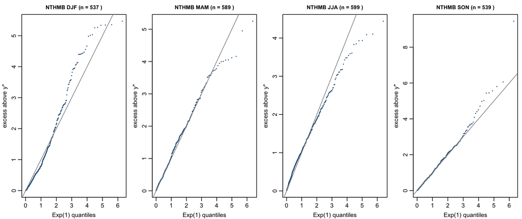

```r
op <- par(mfrow = c(1, 4), mar = c(3, 3, 2, 0.6), mgp = c(1.9, 0.6, 0))
for (sn in c("DJF", "MAM", "JJA", "SON")) {
  e <- YC[seas == sn & YC > y_star] - y_star
  if (length(e) > 10) {
    n <- length(e); th <- -log(1 - (1:n) / (n + 1))
    plot(th, sort(e), pch = 16, cex = 0.4, col = "steelblue4",
         xlab = "Exp(1) quantiles", ylab = "excess above y*",
         main = paste("NTHMB", sn, "(n =", n, ")"), cex.main = 0.9)
    abline(0, 1, col = "grey55")
  } else plot.new()
}
```

```r
par(op)
```

**Reading the figure.** The decisive tail check (v8 3, p. 4): on the Laplace scale the excesses $Y - y^{*}$ above the dependence threshold are exactly unit exponential if the transform is honest, so each season’s exceedances are QQ-plotted against Exp(1). These are the very days the dependence stage consumes — if these panels pass, stage 2 stands on solid ground even where the deep winter body is imperfect. Panel headers carry the exceedance count per season: with a seasonal threshold every season contributes days, and a season with almost none is itself information.

```r
dec_all <- (years - min(years)) %/% 10
share <- t(sapply(list(NTHMB = YC, BRIDG = YX), function(Y)
  round(tapply(Y > y_star, dec_all, mean), 3)))
colnames(share) <- paste0(min(years) + 10 * as.integer(colnames(share)), "s")
knitr::kable(share, caption = sprintf("Share of days above y* = %.3f per
decade; target %.2f in every cell (v8 Sec 3, p. 4 -- the moving threshold's
purpose, LL20).", y_star, 1 - params$tau_star))
```

Share of days above y* = 2.303 per decade; target 0.05 in every cell (v8 Sec 3, p. 4 – the moving threshold’s purpose, LL20).

|  | 1969s | 1979s | 1989s | 1999s | 2009s | 2019s | 2029s | 2039s | 2049s | 2059s | 2069s | 2079s | 2089s | 2099s |
| --- | --- | --- | --- | --- | --- | --- | --- | --- | --- | --- | --- | --- | --- | --- |
| NTHMB | 0.060 | 0.046 | 0.051 | 0.047 | 0.05 | 0.044 | 0.047 | 0.044 | 0.048 | 0.043 | 0.050 | 0.046 | 0.042 | 0.027 |
| BRIDG | 0.094 | 0.087 | 0.048 | 0.031 | 0.05 | 0.034 | 0.028 | 0.020 | 0.045 | 0.039 | 0.038 | 0.060 | 0.036 | 0.027 |

# 6 Stage 2: the dependence model (v8 5, eq. 8, p. 11) — project code

No package fits the non-stationary Heffernan–Tawn model, so this fitter is the project’s one self-implemented core. On the Laplace scale $a(t) \in [-1, 1]$ (link $a = 2\,\mathrm{plogis}(\eta) - 1$) and $b(t) < 1$; the working likelihood stays Gaussian — Keef et al. tested Normal against Laplace working residuals and kept the Normal (v8 5, p. 13) — and the maximization carries the Keef ordering constraint (v8 eq. 9, p. 13): beyond the data the fitted conditional quantiles may not exceed what perfect positive dependence would give, nor undercut perfect negative dependence. The constraint is imposed at $v_K$ above the largest observed conditioning value (v8 3, p. 4), checked at the residual range endpoints, and — our flagged extension — pointwise in $t$ for curve models. Verification is two-tier: the all-constant case against texmex *on its defaults* (Laplace margins, Keef constraints — the reference implementation, v8 4.5, p. 10), and the fixed-$b$ linear case against `mgcv::gam(gaulss)`.

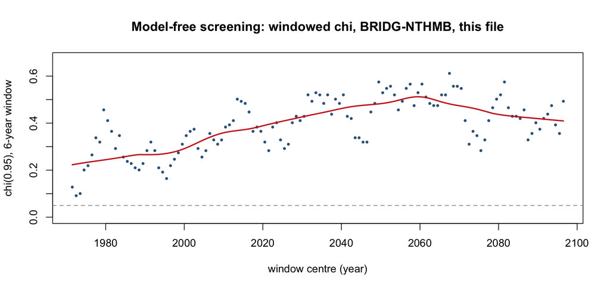

```r
pobs <- function(x) rank(x, ties.method = "average") / (length(x) + 1)
win_chi <- function(c1, c2, y0, y1, u = 0.95) {
  k <- years >= y0 & years <= y1
  uu <- pobs(c1[k]); vv <- pobs(c2[k])
  sum(uu > u & vv > u) / (sum(k) * (1 - u))
}
w_starts <- seq(min(years), max(years) - 5, by = 1)
chi_seq <- sapply(w_starts, function(y0) win_chi(xC, xX, y0, y0 + 5))
plot(w_starts + 2.5, chi_seq, pch = 16, cex = 0.6, col = "steelblue4",
     ylim = c(0, max(chi_seq) * 1.1), xlab = "window centre (year)",
     ylab = "chi(0.95), 6-year window",
     main = "Model-free screening: windowed chi, BRIDG-NTHMB, this file")
lines(lowess(w_starts + 2.5, chi_seq, f = 0.3), col = "firebrick3", lwd = 2)
abline(h = 0.05, lty = 2, col = "grey55")
```

```r
cat(sprintf("windowed chi: mean of first 10 windows %.3f | last 10 %.3f\n",
    mean(head(chi_seq, 10)), mean(tail(chi_seq, 10))))
```

```
## windowed chi: mean of first 10 windows 0.253 | last 10 0.403
```

**Reading the figure.** Each dot is one 6-year window: the share of window days on which *both* stations sit above their own pooled 0.95 rank level, divided by 5% — the empirical χ(0.95). The dashed line at 0.05 is independence; near 1 is asymptotic dependence; the red curve is the smoothed path. No model is involved, so this is the arbiter for the flat fitted a(t): on the previous data generation this statistic drifted from ≈0 to ≈0.4 and selected Case 4 — if the red curve is flat here, the data revision removed the drift and the model is innocent; if it still climbs, the fitted model is losing a real signal, and the per-season table (below) says where.

```r
v_dep <- -log(2 * (1 - params$kappa))
keep <- YC > v_dep
yCe <- YC[keep]; yXe <- YX[keep]; tte <- tt[keep]
fe <- folds[keep]; ye <- years[keep]
n_e <- sum(keep); cat("exceedance days above v =", round(v_dep, 3), ":", n_e, "\n")
```

```
## exceedance days above v = 2.303 : 2264
```

```r
v_K <- max(yCe) + 0.5
zp <- range(yXe - yCe); zm <- range(yXe + yCe)   # Keef bound residual ranges

Bdep <- make_basis(tt, 2 * params$spacing_yr, span_yr)
Bde <- Bdep[keep, , drop = FALSE]
p_dep <- ncol(Bdep)
tdec <- quantile(tte, 0:10 / 10)                  # constraint checked here
keef_on <- TRUE
keef_viol <- function(a_v, b_v, Wlo, Whi) {
  ## ordering (v8 eq. 9, p. 13) at y in {v_K, v_K + 3}, q in {0, 1},
  ## for each (a, b) supplied (deciles of t for curve models)
  if (!keef_on) return(FALSE)
  for (y in c(v_K, v_K + 3)) {
    lo <- a_v * y + y^b_v * Wlo; hi <- a_v * y + y^b_v * Whi
    if (any(hi > y + zp[2]) || any(lo < -y + zm[1])) return(TRUE)
  }
  FALSE
}

ht_nll <- function(theta, yC, yX, Bmat, lambda = 0, w = c(1, 1, 10, 10),
                   Bchk = NULL) {
  p <- ncol(Bmat)
  ga <- theta[1:p]; gb <- theta[(p+1):(2*p)]
  gm <- theta[(2*p+1):(3*p)]; gs <- theta[(3*p+1):(4*p)]
  a <- 2 * plogis(as.vector(Bmat %*% ga)) - 1
  b <- as.vector(Bmat %*% gb)
  m <- as.vector(Bmat %*% gm); s <- exp(as.vector(Bmat %*% gs))
  if (any(b > 0.999)) return(1e10)
  loc <- a * yC + m * yC^b; sc <- s * yC^b
  if (any(!is.finite(sc)) || any(sc <= 0)) return(1e10)
  W <- (yX - a * yC) / yC^b
  if (is.null(Bchk)) Bchk <- Bmat[c(1, nrow(Bmat)), , drop = FALSE]
  a_chk <- 2 * plogis(as.vector(Bchk %*% ga)) - 1
  b_chk <- as.vector(Bchk %*% gb)
  if (keef_viol(a_chk, b_chk, min(W), max(W))) return(1e10)
  sum(log(sc) + 0.5 * ((yX - loc) / sc)^2) +
    lambda * (w[1] * sum(diff(ga)^2) + w[2] * sum(diff(gb)^2) +
              w[3] * sum(diff(gm)^2) + w[4] * sum(diff(gs)^2))
}
fit_ht_basis <- function(yC, yX, Bmat, lambda = 0, init = NULL, Bchk = NULL) {
  p <- ncol(Bmat)
  if (is.null(init)) init <- c(rep(0, p), rep(0.2, p), rep(0, p), rep(0, p))
  optim(init, ht_nll, yC = yC, yX = yX, Bmat = Bmat, lambda = lambda,
        Bchk = Bchk, method = "BFGS", control = list(maxit = 800))
}
curves_of <- function(theta, Bmat) {
  p <- ncol(Bmat)
  list(a = 2 * plogis(as.vector(Bmat %*% theta[1:p])) - 1,
       b = as.vector(Bmat %*% theta[(p+1):(2*p)]),
       m = as.vector(Bmat %*% theta[(2*p+1):(3*p)]),
       s = exp(as.vector(Bmat %*% theta[(3*p+1):(4*p)])))
}
```

```r
B1e <- matrix(1, n_e, 1); B2e <- cbind(1, tte)

## texmex on its own defaults (Laplace margins + Keef constraints) is the
## reference: it sees the already-Laplace pair, so its own marginal step is
## near-identity and tier 1 isolates the dependence fitter
init0 <- NULL
if (has["texmex"]) init0 <- tryCatch({
  tx <- texmex::mex(data.frame(C = YC, X = YX), mqu = params$tau_star,
                    dqu = params$kappa, which = "C")
  co <- tx$dependence$coefficients
  c(qlogis(min(max((co[1, 1] + 1) / 2, 1e-3), 1 - 1e-3)), co[2, 1], 0, 0)
}, error = function(e) NULL)

h0 <- fit_ht_basis(yCe, yXe, B1e, init = init0)
h1 <- fit_ht_basis(yCe, yXe, B2e, init = as.vector(rbind(h0$par, 0)),
                   Bchk = cbind(1, tdec))
LRT_dep <- 2 * (h0$value - h1$value)   # 4 df, working likelihood: guide only

lam_grid_dep <- 10^(0:6)
Bchk_dep <- predict(Bdep, tdec)
cv_dep <- sapply(lam_grid_dep, function(lam) {
  mean(sapply(sort(unique(fe)), function(k) {
    tr <- fe != k
    f <- fit_ht_basis(yCe[tr], yXe[tr], Bde[tr, , drop = FALSE], lam,
                      Bchk = Bchk_dep)
    ht_nll(f$par, yCe[!tr], yXe[!tr], Bde[!tr, , drop = FALSE], 0,
           Bchk = Bchk_dep) / sum(!tr)
  }))
})
lam_dep <- lam_grid_dep[which.min(cv_dep)]
hs <- fit_ht_basis(yCe, yXe, Bde, lam_dep,
        init = c(rep(h0$par[1], p_dep), rep(h0$par[2], p_dep),
                 rep(h0$par[3], p_dep), rep(h0$par[4], p_dep)),
        Bchk = Bchk_dep)

## model selection, printed: the spline is kept only if it beats the line
## at its own game (a worse penalized fit = collapse or the a-m ridge)
spline_ok <- hs$value < h1$value
sel <- if (spline_ok) list(par = hs$par, B = Bdep, label = "spline") else
                      list(par = h1$par, B = cbind(1, tt), label = "linear")
cs_sel <- curves_of(sel$par, sel$B)
cat("selected dependence model:", sel$label, "\n")
```

```
## selected dependence model: linear
```

```r
knitr::kable(data.frame(
  model = c("all constant", "all linear", "spline (penalized)"),
  working_nll = round(c(h0$value, h1$value, hs$value), 1),
  note = c(sprintf("a = %.3f, b = %.3f%s", 2 * plogis(h0$par[1]) - 1,
                   h0$par[2], ifelse(is.null(init0), "", " (texmex-seeded)")),
           sprintf("LRT(4df) = %.2f -- approximate guide; the bootstrap
                    interval is the honest test (v8 Sec 4.6, p. 10)", LRT_dep),
           sprintf("lambda_dep = %g by blocked CV; %s", lam_dep,
                   ifelse(spline_ok, "kept", "rejected (collapse) -- linear
                   selected for all downstream output")))),
  caption = "Dependence stage, Case 4 (BRIDG | NTHMB), v8 Sec 5 eq. (8)
  p. 11, Laplace scale, Keef constraints active.")
```

Dependence stage, Case 4 (BRIDG | NTHMB), v8 Sec 5 eq. (8) p. 11, Laplace scale, Keef constraints active.

[output not shown]

```r
sdep <- do.call(rbind, lapply(c("DJF", "MAM", "JJA", "SON"), function(sn) {
  k <- keep & seas == sn
  f <- fit_ht_basis(YC[k], YX[k], matrix(1, sum(k), 1))
  data.frame(season = sn, n = sum(k),
             a_hat = round(2 * plogis(f$par[1]) - 1, 3),
             b_hat = round(f$par[2], 3))
}))
knitr::kable(sdep, row.names = FALSE, caption = "Constant HT fit per season
of the conditioning day. A high-freshet / low-winter pattern says the flat
pooled a(t) is dilution by the season-relative conditioning event -- the
seasonal threshold made 'NTHMB extreme' include winter days whose
co-movement with BRIDG is weak -- not absence of dependence.")
```

Constant HT fit per season of the conditioning day. A high-freshet / low-winter pattern says the flat pooled a(t) is dilution by the season-relative conditioning event – the seasonal threshold made ‘NTHMB extreme’ include winter days whose co-movement with BRIDG is weak – not absence of dependence.

| season | n | a_hat | b_hat |
| --- | --- | --- | --- |
| DJF | 537 | -0.055 | 0.650 |
| MAM | 589 | 0.141 | 0.411 |
| JJA | 599 | 0.172 | 0.031 |
| SON | 539 | -0.011 | 0.673 |

```r
## freshet-only (May-Aug): the original science question, co-flooding in
## flood season, on the new margins
kF <- keep & months %in% 5:8
h0F <- fit_ht_basis(YC[kF], YX[kF], matrix(1, sum(kF), 1))
h1F <- fit_ht_basis(YC[kF], YX[kF], cbind(1, tt[kF]),
                    init = as.vector(rbind(h0F$par, 0)), Bchk = cbind(1, tdec))
cat(sprintf("freshet-only (n = %d): constant a = %.3f, b = %.3f |
  linear LRT(4df) = %.2f, a(t) endpoints %.3f -> %.3f\n",
  sum(kF), 2 * plogis(h0F$par[1]) - 1, h0F$par[2],
  2 * (h0F$value - h1F$value),
  2 * plogis(h1F$par[1]) - 1, 2 * plogis(h1F$par[1] + h1F$par[2]) - 1))
```

```
## freshet-only (n = 781): constant a = 0.227, b = 0.065 |
##   linear LRT(4df) = 13.92, a(t) endpoints 0.443 -> -0.245
```

```r
keef_on <- FALSE
h1_free <- fit_ht_basis(yCe, yXe, B2e, init = as.vector(rbind(h0$par, 0)))
keef_on <- TRUE
cat(sprintf("linear fit, constraint OFF: nll %.1f (constrained %.1f) |
  a(t) endpoints %.3f -> %.3f (constrained: %.3f -> %.3f)\n",
  h1_free$value, h1$value,
  2 * plogis(h1_free$par[1]) - 1,
  2 * plogis(h1_free$par[1] + h1_free$par[2]) - 1,
  2 * plogis(h1$par[1]) - 1, 2 * plogis(h1$par[1] + h1$par[2]) - 1))
```

```
## linear fit, constraint OFF: nll 2022.2 (constrained 2698.6) |
##   a(t) endpoints 0.396 -> 0.490 (constrained: 0.095 -> 0.095)
```

If the free fit lands on the same nll and the same flat endpoints, the zero slope is genuine; if it finds a lower nll and a real slope, the constraint’s hard 1e10 wall was stalling BFGS and I’ll rework the constraint as a soft penalty.

## 6.1 Tier 1: texmex on its defaults (all-constant case)

```r
co <- tx$dependence$coefficients
knitr::kable(data.frame(
  parameter = c("a", "b"),
  project = round(c(2 * plogis(h0$par[1]) - 1, h0$par[2]), 4),
  texmex = round(co[1:2, 1], 4)),
  caption = "Tier 1: all-constant project fit vs texmex on its own defaults
  (Laplace margins, Keef constraints -- the reference implementation, v8
  Sec 4.5 p. 10), both on the SAME Laplace-scale pair so the margins are
  shared and the gap isolates the fitter. The gap should be small; a large
  one is a fitter problem to investigate, not to explain away. (The Keef
  implementations differ in detail: texmex imposes Theorem 1 exactly, the
  project fitter checks the ordering at the residual range endpoints.)")
```

Tier 1: all-constant project fit vs texmex on its own defaults (Laplace margins, Keef constraints – the reference implementation, v8 Sec 4.5 p. 10), both on the SAME Laplace-scale pair so the margins are shared and the gap isolates the fitter. The gap should be small; a large one is a fitter problem to investigate, not to explain away. (The Keef implementations differ in detail: texmex imposes Theorem 1 exactly, the project fitter checks the ordering at the residual range endpoints.)

|  | parameter | project | texmex |
| --- | --- | --- | --- |
| a | a | 0.0950 | 0.0807 |
| b | b | 0.4246 | 0.4020 |

## 6.2 Tier 2: the mgcv check (fixed $b$, linear curves)

With $b$ frozen at $\hat b$ and the remaining curves linear, the model is a varying-coefficient Gaussian location-scale model — mean $= a(t)y + m(t)y^{b}$, log sd $= \log s(t) + b \log y$ — which `mgcv::gam(gaulss)` fits by ML. Same model, two optimizers; the fitted means must agree. To keep it literally the same model, the check fitter uses an identity link for $a(t)$ (mgcv’s varying coefficient is linear in $t$); the production fitter’s bounded link and Keef constraint are deliberately not part of what this tier tests.

```r
b0 <- h0$par[2]
## identity link for a(t) HERE ONLY: tier 2 is same-model-two-optimizers,
## and mgcv's varying coefficient is linear in t, so the check model must
## be too -- the production fitter's bounded link is not what is tested
ht_nll_fixedb <- function(th, yC, yX, ttv, b0) {
  a <- th[1] + th[2] * ttv
  m <- th[3] + th[4] * ttv; s <- exp(th[5] + th[6] * ttv)
  loc <- a * yC + m * yC^b0; sc <- s * yC^b0
  sum(log(sc) + 0.5 * ((yX - loc) / sc)^2)
}
thf <- optim(c(2 * plogis(h0$par[1]) - 1, 0, h0$par[3], 0, h0$par[4], 0),
             ht_nll_fixedb, yC = yCe, yX = yXe, ttv = tte, b0 = b0,
             method = "BFGS", control = list(maxit = 2000))
a_f <- thf$par[1] + thf$par[2] * tte
loc_own <- a_f * yCe + (thf$par[3] + thf$par[4] * tte) * yCe^b0
sc_own  <- exp(thf$par[5] + thf$par[6] * tte) * yCe^b0

yCb <- yCe^b0
gmfit <- mgcv::gam(list(yXe ~ -1 + yCe + I(tte * yCe) + yCb + I(tte * yCb),
                        ~ tte + offset(b0 * log(yCe))),
                   family = mgcv::gaulss())
lp <- predict(gmfit)
loc_m <- lp[, 1]
sd_a <- exp(lp[, 2]); sd_b <- 1 / (exp(lp[, 2]) + 0.01)
pick <- which.min(abs(c(sd((yXe - loc_m) / sd_a),
                        sd((yXe - loc_m) / sd_b)) - 1))
sc_m <- if (pick == 1) sd_a else sd_b

t2 <- c(loc_rel = max(abs(loc_own - loc_m)) / diff(range(yXe)),
        sc_rel = median(abs(sc_own - sc_m) / sc_own))
stopifnot(t2["loc_rel"] < 0.02)
knitr::kable(data.frame(check = c("conditional mean (max gap, range units)",
                                  "conditional sd (median relative gap)"),
                        value = signif(t2, 3)),
             caption = "Tier 2: project fitter (b fixed, linear curves,
             unconstrained) vs mgcv::gam(gaulss) on the identical model.
             Mean structure asserted at 2%; sd reported (link-convention
             sensitive). Note the mgcv fit carries no Keef constraint, so
             the project fitter runs this case unconstrained too -- the
             comparison is only clean like for like.")
```

Tier 2: project fitter (b fixed, linear curves, unconstrained) vs mgcv::gam(gaulss) on the identical model. Mean structure asserted at 2%; sd reported (link-convention sensitive). Note the mgcv fit carries no Keef constraint, so the project fitter runs this case unconstrained too – the comparison is only clean like for like.

|  | check | value |
| --- | --- | --- |
| loc_rel | conditional mean (max gap, range units) | 3.43e-05 |
| sc_rel | conditional sd (median relative gap) | 6.64e-03 |

## 6.3 Diagnostics and the anchor (v8 5, pp. 11–12)

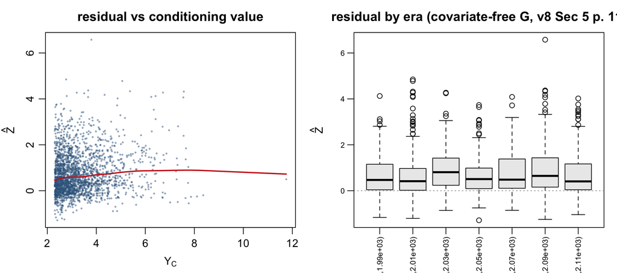

```r
a_e <- if (sel$label == "spline") curves_of(sel$par, Bde) else
       curves_of(sel$par, cbind(1, tte))
Zhat <- ((yXe - a_e$a * yCe) / yCe^a_e$b - a_e$m) / a_e$s
op <- par(mfrow = c(1, 2), mar = c(3.5, 3.5, 2.5, 1), mgp = c(2.2, 0.7, 0))
plot(yCe, Zhat, pch = 16, cex = 0.4, col = adjustcolor("steelblue4", 0.5),
     xlab = expression(Y[C]), ylab = expression(hat(Z)),
     main = "residual vs conditioning value")
lines(lowess(yCe, Zhat, f = 0.5), col = "firebrick3", lwd = 2)
era_e <- cut(ye, seq(min(years), max(years) + 20, by = 20), right = FALSE)
boxplot(Zhat ~ era_e, col = "grey92", las = 2, cex.axis = 0.7,
        xlab = "", ylab = expression(hat(Z)),
        main = "residual by era (covariate-free G, v8 Sec 5 p. 11)")
abline(h = 0, lty = 3, col = "grey60")
```

```r
par(op)
Ztable <- Zhat
```

**Reading the figure.** Left: x-axis the conditioning value $Y_C$ (Laplace scale, above $v$), y-axis the standardized residual from the *selected* model; the red line is a running mean. Flat at zero with constant scatter says the fitted curves absorbed everything systematic; drift in level or spread says the normalization failed (v8 5, p. 11). Right: the residuals by era — equal boxes are the covariate-free-$G$ assumption, the licence for reusing any era’s residual at any other $t$ (v8 5, p. 12).

```r
mA_C <- fit_ladder(get_series(A_C, "sf")); gA_C <- fit_gp_stage(get_series(A_C, "sf"), mA_C)
```

[output not shown]

```
## evgam vs project sigma(t): max relative gap 1.733 (REML vs
##     CV smoothing; reported, not asserted)
```

```r
mA_X <- fit_ladder(get_series(A_X, "sf")); gA_X <- fit_gp_stage(get_series(A_X, "sf"), mA_X)
```

[output not shown]

```
## evgam vs project sigma(t): max relative gap 1.419 (REML vs
##     CV smoothing; reported, not asserted)
```

```r
YA_C <- qlap(F_of(get_series(A_C, "sf"), mA_C, gA_C))
```

```
##   below bottom rung: 16 days (0.03%); at numerical floor: 0
```

```r
YA_X <- qlap(F_of(get_series(A_X, "sf"), mA_X, gA_X))
```

```
##   below bottom rung: 38 days (0.08%); at numerical floor: 0
```

```r
ka <- YA_C > v_dep
h_anchor <- fit_ht_basis(YA_C[ka], YA_X[ka], matrix(1, sum(ka), 1))
cat(sprintf("Case 1 anchor: a-hat = %.3f (must sit near 1; v8 Sec 5 p. 12),
            b-hat = %.3f\n", 2 * plogis(h_anchor$par[1]) - 1, h_anchor$par[2]))
```

```
## Case 1 anchor: a-hat = 1.000 (must sit near 1; v8 Sec 5 p. 12),
##             b-hat = -0.210
```

# 7 The conditional-simulation display (meeting 62, rebuilt)

Two decisions from the meeting shape this section. *Condition on the day of year*: a randomly picked date lands in low-flow seasons and the simulated points come out smaller than the real extremes; the display day is now the climatological freshet peak (the day of year at which the fitted threshold is highest), a parameter of this chunk. *No year colours on the standard scale*: after the marginal transform every day is the same Laplace distribution, so the standard-margins panel shows one model cloud against the data; the year contrast appears only on the original scale, where the margins genuinely differ by year — and the scenario contrast (RCP 4.5 against 8.5) takes over as the headline comparison once the 8.5 export joins the file. Which scale the paper’s version uses is the open display question for Friday; both are drawn here.

```r
## reverse direction fitted with the same machinery (v8 Sec 5, p. 11)
keepR <- YX > v_dep
hR <- fit_ht_basis(YX[keepR], YC[keepR], cbind(1, tt[keepR]),
                   Bchk = cbind(1, tdec))
csR <- curves_of(hR$par, cbind(1, tt[keepR]))
ZtabR <- ((YC[keepR] - csR$a * YX[keepR]) / YX[keepR]^csR$b - csR$m) / csR$s

doy_star <- as.integer(names(which.max(tapply(mX$U[, K], doy, mean))))
Yr_mid <- round(mean(range(years)))
cat("display day of year (freshet peak):", doy_star,
    "| standard-scale reference year:", Yr_mid, "\n")
```

```
## display day of year (freshet peak): 187 | standard-scale reference year: 2034
```

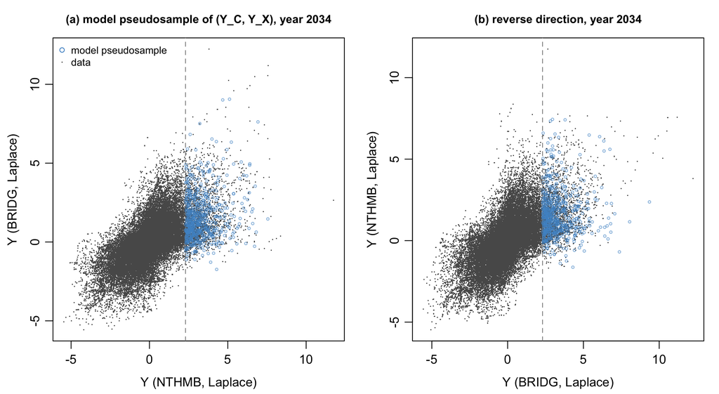

```r
gen_pseudo <- function(a, b, m, s, Ztab, n = 600) {
  yc <- qlap(params$kappa + (1 - params$kappa) * runif(n))
  z <- sample(Ztab, n, replace = TRUE)
  cbind(yc = yc, yx = a * yc + yc^b * (m + s * z))
}
at_day <- function(cv, Yr) {          # selected-model curves on one day
  i <- which(years == Yr & doy == doy_star)[1]
  if (is.na(i)) i <- which(years == Yr & doy == doy_star - 1)[1]
  list(a = cv$a[i], b = cv$b[i], m = cv$m[i], s = cv$s[i], idx = i)
}
cs_full <- curves_of(sel$par, if (sel$label == "spline") Bdep else cbind(1, tt))
csR_full <- curves_of(hR$par, cbind(1, tt))

op <- par(mfrow = c(1, 2), mar = c(3.5, 3.5, 2.5, 1), mgp = c(2.2, 0.7, 0))
pd <- at_day(cs_full, Yr_mid)
plot(YC, YX, pch = ".", col = "grey35",
     xlab = "Y (NTHMB, Laplace)", ylab = "Y (BRIDG, Laplace)",
     main = sprintf("(a) model pseudosample of (Y_C, Y_X), year %d", Yr_mid),
     cex.main = 0.9)
abline(v = v_dep, lty = 2, col = "grey55")
ps <- gen_pseudo(pd$a, pd$b, pd$m, pd$s, Ztable)
points(ps[, 1], ps[, 2], cex = 0.45, col = adjustcolor("steelblue3", 0.6))
legend("topleft", c("model pseudosample", "data"),
       col = c("steelblue3", "grey35"), pch = c(1, 46), bty = "n", cex = 0.8)
pdR <- at_day(csR_full, Yr_mid)
plot(YX, YC, pch = ".", col = "grey35",
     xlab = "Y (BRIDG, Laplace)", ylab = "Y (NTHMB, Laplace)",
     main = sprintf("(b) reverse direction, year %d", Yr_mid),
     cex.main = 0.9)
abline(v = v_dep, lty = 2, col = "grey55")
psR <- gen_pseudo(pdR$a, pdR$b, pdR$m, pdR$s, ZtabR)
points(psR[, 1], psR[, 2], cex = 0.45, col = adjustcolor("steelblue3", 0.6))
```

```r
par(op)
```

**Reading the figure.** Both axes are Laplace-scale values; panel (a) conditions on NTHMB (x-axis), panel (b) on BRIDG. Dots are all observed days; the dashed line is the dependence threshold $v$; circles are the model’s pseudosample to the right of $v$, generated at the freshet-peak day of the mid-axis year. The eye’s goodness-of-fit test: circles living where dots live is agreement; circles beyond the largest dots are the extrapolation, shown rather than asserted. One colour only: on this scale the margins carry no year, so a year contrast here would draw a distinction the axes cannot show (the joint drift is real but lives in the dependence curves; it is quantified by the fitted $a(t)$ and the functionals below, and displayed on the original scale next). Comparing panels (a) and (b) is the self-consistency caution (v8 5, p. 11).

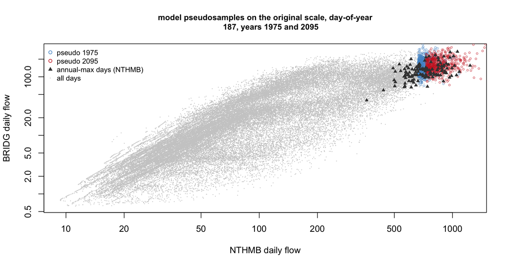

```r
q_inv <- function(p, ladder, gp, idx) {
  U <- ladder$U[idx, ]; sig <- gp$sig[idx]; xi <- gp$xi
  beta1 <- (U[2] - U[1]) / log(taus[2] / taus[1])
  sapply(p, function(pp) {
    if (pp >= params$tau_star)
      U[K] + sig / xi * (((1 - params$tau_star) / (1 - pp))^xi - 1)
    else if (pp < taus[1]) U[1] + beta1 * log(pp / taus[1])
    else {
      k <- max(which(taus <= pp))
      if (k == K) U[k]
      else U[k] + (U[k + 1] - U[k]) * (pp - taus[k]) / (taus[k + 1] - taus[k])
    }
  })
}
yr_show <- c(params$start_year + 6, max(years) - 4)
cols2 <- c("steelblue3", "firebrick3")
plot(xC, xX, pch = ".", col = "grey80", log = "xy",
     xlab = "NTHMB daily flow", ylab = "BRIDG daily flow",
     main = sprintf("model pseudosamples on the original scale, day-of-year
     %d, years %d and %d", doy_star, yr_show[1], yr_show[2]), cex.main = 0.9)
for (e in 1:2) {
  pdE <- at_day(cs_full, yr_show[e])
  ps <- gen_pseudo(pdE$a, pdE$b, pdE$m, pdE$s, Ztable)
  xc_o <- q_inv(pmin(plap(ps[, 1]), 1 - 1e-9), mC, gC, pdE$idx)
  xx_o <- q_inv(pmin(pmax(plap(ps[, 2]), 1 / (4 * N)), 1 - 1e-9), mX, gX, pdE$idx)
  points(xc_o, xx_o, cex = 0.45, col = adjustcolor(cols2[e], 0.55))
}
amx <- tapply(seq_len(N), years, function(i) i[which.max(xC[i])])
points(xC[amx], xX[amx], pch = 17, cex = 0.7, col = "grey25")
legend("topleft", c(paste("pseudo", yr_show[1]), paste("pseudo", yr_show[2]),
                    "annual-max days (NTHMB)", "all days"),
       col = c(cols2, "grey25", "grey80"), pch = c(1, 1, 17, 46),
       bty = "n", cex = 0.8)
```

**Reading the figure.** The same pseudosamples pushed back through each day’s fitted margins onto the original flow scale (log axes), generated at the freshet-peak day of an early and a late year — here the year contrast is meaningful, because the margins differ by year on this scale. The dark triangles are the observed annual-maximum days of the conditioning station: the meeting’s complaint — simulated points smaller than the real extremes — is the check here; with day-of-year conditioning the clouds must reach and extend the triangles’ territory. The blue-to-red movement is the whole fitted change — margins and dependence together; whether the paper shows this original-scale version or the standard-scale one is the Friday question, and the scenario contrast will replace the year contrast once RCP 8.5 is in the file.

# 8 Stage 3: extremal index (v8 6, eq. 13, p. 15)

```r
ferro_segers <- function(exc_idx) {
  Ti <- diff(exc_idx); n <- length(exc_idx)
  if (max(Ti) <= 2) min(1, 2 * sum(Ti)^2 / ((n - 1) * sum(Ti^2)))
  else min(1, 2 * sum(Ti - 1)^2 / ((n - 1) * sum((Ti - 1) * (Ti - 2))))
}
theta_route <- function(x, u) {
  own <- ferro_segers(which(x > u))
  if (has["extRemes"]) {
    pkg <- tryCatch(as.numeric(
      extRemes::extremalindex(x - u, threshold = 0, method = "intervals")[1]),
      error = function(e) NA)
    if (!is.na(pkg)) {
      cat(sprintf("theta: extRemes %.3f | project %.3f (consistency)\n",
                  pkg, own))
      return(pkg)
    }
  }
  own
}
thC <- theta_route(xC, mC$U[, K])
```

```
## theta: extRemes 0.244 | project 0.244 (consistency)
```

```r
thX <- theta_route(xX, mX$U[, K])
```

```
## theta: extRemes 0.127 | project 0.127 (consistency)
```

```r
cat(sprintf("theta: NTHMB %.3f (mean run %.1f d), BRIDG %.3f (%.1f d)\n",
            thC, 1 / thC, thX, 1 / thX))
```

```
## theta: NTHMB 0.244 (mean run 4.1 d), BRIDG 0.127 (7.9 d)
```

# 9 Stage 4: return levels (v8 6, eqs. 10–13, pp. 14–15)

```r
rl_root <- function(Yr, Ts, U, sig, xi, theta) {
  idx <- which(years == Yr)
  u <- U[idx, K]; s <- sig[idx]
  logPr <- function(x, th) {
    z <- pmax(1 + xi * (x - u) / s, 0)
    p <- (1 - params$tau_star) * ifelse(x > u, z^(-1 / xi), 1)
    th * sum(log(pmax(1 - p, 1e-12)))
  }
  sapply(Ts, function(T)
    tryCatch(uniroot(function(x) logPr(x, theta) - log(1 - 1 / T),
                     c(max(u) * 1.0001, max(u) + 80 * max(s)))$root,
             error = function(e) NA))
}
Ygrid <- seq(min(years) + 2, max(years) - 2, by = 5)
Ts <- c(10, 50, 100)
rlC <- t(sapply(Ygrid, rl_root, Ts = Ts, U = mC$U, sig = gC$sig,
                xi = gC$xi, theta = thC))
rlX <- t(sapply(Ygrid, rl_root, Ts = Ts, U = mX$U, sig = gX$sig,
                xi = gX$xi, theta = thX))

## Route A vs Route B at theta = 1: the machinery check (v8 Sec 6, p. 15)
Yr0 <- Ygrid[which.min(abs(Ygrid - median(Ygrid)))]
idx0 <- which(years == Yr0)
u0 <- mX$U[idx0, K]; s0 <- gX$sig[idx0]
n_sim <- 4000
sim_max <- replicate(n_sim, {
  exc <- runif(length(idx0)) < (1 - params$tau_star)
  if (!any(exc)) return(max(u0))
  ex <- which(exc)
  max(u0[ex] + s0[ex] / gX$xi * (runif(length(ex))^(-gX$xi) - 1))
})
routeA_1 <- rl_root(Yr0, Ts, mX$U, gX$sig, gX$xi, theta = 1)
routeB_1 <- quantile(sim_max, 1 - 1 / Ts)
knitr::kable(data.frame(T = Ts, routeA = round(routeA_1, 1),
                        routeB = round(routeB_1, 1),
                        rel_gap = signif(abs(routeA_1 - routeB_1) / routeA_1, 2)),
             caption = sprintf("Route A vs Route B at theta = 1, year %d,
             BRIDG (%d simulated years). Small gaps validate the chaining
             machinery before the theta correction is trusted.", Yr0, n_sim))
```

Route A vs Route B at theta = 1, year 2031, BRIDG (4000 simulated years). Small gaps validate the chaining machinery before the theta correction is trusted.

|  | T | routeA | routeB | rel_gap |
| --- | --- | --- | --- | --- |
| 90% | 10 | 259.7 | 258.7 | 0.0039 |
| 98% | 50 | 311.4 | 306.6 | 0.0160 |
| 99% | 100 | 336.8 | 339.8 | 0.0090 |

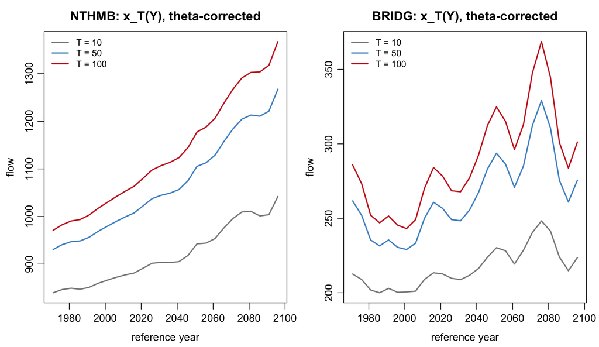

```r
op <- par(mfrow = c(1, 2), mar = c(3.5, 3.5, 2.5, 1), mgp = c(2.2, 0.7, 0))
cols <- c("grey55", "steelblue3", "firebrick3")
for (nm in list(list(rlC, "NTHMB"), list(rlX, "BRIDG"))) {
  matplot(Ygrid, nm[[1]], type = "l", lty = 1, lwd = 2, col = cols,
          xlab = "reference year", ylab = "flow",
          main = paste0(nm[[2]], ": x_T(Y), theta-corrected"))
  legend("topleft", paste0("T = ", Ts), col = cols, lwd = 2, bty = "n",
         cex = 0.85)
}
```

```r
par(op)
```

**Reading the figure.** The x-axis is the reference year $Y$; the y-axis the flow level $x_T(Y)$ a year with year-$Y$’s climate exceeds with probability $1/T$ (v8 eq. 10, p. 14 — a probability statement about a reference year, not a forecast). One curve per return period, corrected by $\theta$ for clustering (v8 eq. 13, p. 15). Rising = intensification; falling is physically possible on snowmelt rivers; the horizontal reading — the level that was a 100-year event early becoming a 50-year event late — is the paper’s most quotable sentence, once the bootstrap bands of the uncertainty section are around the curves.